# DATA 698: Masters Research Project

Gabriella Martinez & Gabriel Campos

Last edited December 20, 2024

# Packages

```r
#load libraries
library(car)
library(caret)
library(corrplot)
library(DT)
library(dplyr)
library(ggplot2)
library(janitor)
library(Hmisc)
library(knitr)
library(randomForest)
library(reshape2)
library(rvest)
library(tidyverse)
library(tidycensus)
library(httr)
library(xml2)
library(kableExtra)
```

```r
# Define the path to the Key folder
api_key_file_path <- file.path(".", "Key", "api_key.txt")

# Read the API key from the file
api_key <- readLines(api_key_file_path, warn = FALSE)

# Print the API key (for debugging purposes; avoid doing this in production)
cat("API Key:", api_key, "\n")
```

```
API Key: 60a577bbf5f66f4985ca219cc061a2a6a7d7b52f
```

# Data Load

## Election Data

Data was source from [**Harvard Dataverse**](https://data.harvard.edu/dataverse), an open-source data repository platform developed by [Harvard University](https://www.harvard.edu). It is designed to facilitate the sharing, preservation, and citation of research data across various disciplines. Harvard Dataverse is part of the larger Dataverse Project, which provides an open-source platform for institutions to host their own Dataverse installations. The data was extracted to *countypres_2000-2020.csv* and loaded onto our projects github.

```r
# Data sourced
#https://dataverse.harvard.edu/dataset.xhtml?persistentId=doi:10.7910/DVN/VOQCHQ
# Retrieved from github and stored onto elections dataframe

elect_df <- read_csv(paste0(git_url,"countypres_2000-2020.csv"))
#glimpse(elections)
```

```r
elect_df%>%
  group_by(party)%>%
  summarise(count = n())%>%
  kable()
```

| party | count |
| --- | --- |
| DEMOCRAT | 20906 |
| GREEN | 6035 |
| LIBERTARIAN | 4955 |
| OTHER | 19815 |
| REPUBLICAN | 20906 |

### Data Cleaning (Elections)

```r
#identify empty and NA values. 57 NA values in the county_fips column
colSums(elect_df == "" | is.na(elect_df))
```

```
          year          state       state_po    county_name    county_fips         office      candidate          party candidatevotes     totalvotes        version           mode
             0              0              0              0             57              0              0              0              0              0              0              0
```

```r
elect_df %>%
  filter(is.na(county_fips))
```

| year | state | state_po | county_name | county_fips | office | candidate | party | candidatevotes | totalvotes | version | mode |
| --- | --- | --- | --- | --- | --- | --- | --- | --- | --- | --- | --- |
| 2000 | CONNECTICUT | CT | STATEWIDE WRITEIN | NA | US PRESIDENT | AL GORE | DEMOCRAT | 0 | 0 | 20220315 | TOTAL |
| 2000 | MAINE | ME | MAINE UOCAVA | NA | US PRESIDENT | AL GORE | DEMOCRAT | 0 | 0 | 20220315 | TOTAL |
| 2000 | RHODE ISLAND | RI | FEDERAL PRECINCT | NA | US PRESIDENT | AL GORE | DEMOCRAT | 0 | 0 | 20220315 | TOTAL |
| 2000 | CONNECTICUT | CT | STATEWIDE WRITEIN | NA | US PRESIDENT | GEORGE W. BUSH | REPUBLICAN | 0 | 0 | 20220315 | TOTAL |
| 2000 | MAINE | ME | MAINE UOCAVA | NA | US PRESIDENT | GEORGE W. BUSH | REPUBLICAN | 0 | 0 | 20220315 | TOTAL |
| 2000 | RHODE ISLAND | RI | FEDERAL PRECINCT | NA | US PRESIDENT | GEORGE W. BUSH | REPUBLICAN | 0 | 0 | 20220315 | TOTAL |
| 2000 | CONNECTICUT | CT | STATEWIDE WRITEIN | NA | US PRESIDENT | RALPH NADER | GREEN | 0 | 0 | 20220315 | TOTAL |
| 2000 | MAINE | ME | MAINE UOCAVA | NA | US PRESIDENT | RALPH NADER | GREEN | 0 | 0 | 20220315 | TOTAL |
| 2000 | RHODE ISLAND | RI | FEDERAL PRECINCT | NA | US PRESIDENT | RALPH NADER | GREEN | 0 | 0 | 20220315 | TOTAL |
| 2000 | CONNECTICUT | CT | STATEWIDE WRITEIN | NA | US PRESIDENT | OTHER | OTHER | 0 | 0 | 20220315 | TOTAL |

[output cut: 47 more lines]

```r
elect_df %>%
  filter(is.na(county_fips)) %>%
  select(state_po, county_name, county_fips) %>%
  distinct() %>%
  kable(caption = "Counties with NA FIPS")%>%
  kable_classic()
```

Counties with NA FIPS

| state_po | county_name | county_fips |
| --- | --- | --- |
| CT | STATEWIDE WRITEIN | NA |
| ME | MAINE UOCAVA | NA |
| RI | FEDERAL PRECINCT | NA |
| DC | DISTRICT OF COLUMBIA | NA |

```r
#clean elections data
elect_data_df <- elect_df %>%
  #new name = old name
  rename(state_abbr = state_po, pol_identity = party, FIPS = county_fips) %>%
  mutate(FIPS = ifelse(state_abbr == "DC", "11001", FIPS))

#there are 52 NAs remaining
elect_nas_df <- elect_data_df %>%
  filter(is.na(FIPS))

elect_nas_df %>%
  count(state_abbr, county_name)%>%
  kable(caption = "Vote Counts by Party")%>%
  kable_minimal()
```

Vote Counts by Party

| state_abbr | county_name | n |
| --- | --- | --- |
| CT | STATEWIDE WRITEIN | 16 |
| ME | MAINE UOCAVA | 16 |
| RI | FEDERAL PRECINCT | 20 |

The remaining **NA** values in the **FIPS** column are votes assigned at a state-wide level, not to any count. The *“MAINE UOCAVA”* county record for the state of Maine represents the count of votes from Uniformed Service & Overseas [**(UOCAVA)**](https://www.maine.gov/sos/cec/elec/voter-info/uocava.html) Voters. The [“STATEWIDE WRITEIN”](https://www.usa.gov/write-in-candidates) for Connecticut represents the count of votes for self-selected candidates not on the presidential ballot. It is unclear what the *“FEDERAL PRECINCT”* for the state of Rhode Island exactly represents. Either way, our analysis will be conducted at the county level, so these records cannot be used.

Next we will assess the effect that removing these votes will have on our overall analysis.

```r
#nas
nrow(elect_nas_df)
```

```
[1] 52
```

```r
# Determine the total number of records in the table.
nrow(elect_nas_df)
```

```
[1] 52
```

```r
round(nrow(elect_nas_df)/nrow(elect_data_df)*100,3)
```

```
[1] 0.072
```

```r
# Determine the total number of votes cast across all counties in all elections.
elect_vt_cnt_df <- elect_data_df %>%
  summarise(count= sum(candidatevotes))

elect_vt_cnt_df
```

| count |
| --- |
| 782944050 |

```r
# Determine how many votes are associated with state-level counts
elect_null_fips_cnt_df <- elect_nas_df %>%
  summarise(count=sum(candidatevotes))

elect_null_fips_cnt_df
```

| count |
| --- |
| 13009 |

```r
round((elect_null_fips_cnt_df$count/elect_vt_cnt_df$count)*100,3)
```

```
[1] 0.002
```

There were 52 records with state-level counts and null FIPS values in the data, representing 13009 votes. This amounts to 0.072% of the total records and 0.002% of the total votes.

The records with state-level counts and null FIPS values represent a small percentage of the total, and they are unlikely to change the overall analysis. Given our assessment, the records will be removed.

```r
#transform data- drop NAs, keep dem and gop only, group records for each candidate by county and year
elect_cand_vt_df <- elect_data_df %>%
  filter(!is.na(FIPS), pol_identity %in% c('DEMOCRAT', 'REPUBLICAN')) %>%
  group_by(FIPS,county_name,
           state, candidate,
           year, pol_identity,
           totalvotes) %>%
  summarise(candidate_votes = sum(candidatevotes)) %>%
  ungroup() %>%
  arrange(FIPS, year)
#spread the candidate votes values
elect_pivot_df <- elect_cand_vt_df %>%
   pivot_wider(id_cols = c(year, FIPS, county_name, state, totalvotes),
               names_from = pol_identity,
               values_from = candidate_votes) %>%
  rename(votes_dem = DEMOCRAT,  votes_gop = REPUBLICAN
         #votes_other = OTHER,votes_grn = GREEN, votes_lib = LIBERTARIAN
         )

head(elect_pivot_df)%>%
  kable%>%
  kable_classic()
```

| year | FIPS | county_name | state | totalvotes | votes_dem | votes_gop |
| --- | --- | --- | --- | --- | --- | --- |
| 2000 | 01001 | AUTAUGA | ALABAMA | 17208 | 4942 | 11993 |
| 2004 | 01001 | AUTAUGA | ALABAMA | 20081 | 4758 | 15196 |
| 2008 | 01001 | AUTAUGA | ALABAMA | 23641 | 6093 | 17403 |
| 2012 | 01001 | AUTAUGA | ALABAMA | 23932 | 6363 | 17379 |
| 2016 | 01001 | AUTAUGA | ALABAMA | 24973 | 5936 | 18172 |
| 2020 | 01001 | AUTAUGA | ALABAMA | 27770 | 7503 | 19838 |

## Census Bureau data

About Census Bureau American Community Survey (ACS) data https://www.census.gov/programs-surveys/acs/guidance/estimates.html

### Citizen Voting Age Population

Citizen Voting Age Population, Census Bureau population estimates generated using the American Community Survey

```r
#CVAP- Citizen Voting Age Population, Census Bureau population estimates
#generated using the American Community Survey

#https://www.census.gov/programs-surveys/decennial-census/about/voting-rights
#/cvap.2010.html#list-tab-1518558936 (2008)
cens_cvap2008 <-
  read_csv(paste0(git_url,
                  "CountyCVAP_2006-2010.csv"
                  # ,"?token=GHSAT0AAAAAACXYKDAYQCHUVJY2V6BVWU7SZXPAZJQ"
                  )) %>%
  rename_with(tolower) %>%
  mutate(year=2008)

#https://www.census.gov/programs-surveys/decennial-census/about/voting-rights
#/cvap.2014.html#list-tab-1518558936 (2012)
cens_cvap2012 <-
  read_csv(paste0(git_url,
           "CountyCVAP_2010-2014.csv"
           #,"?token=GHSAT0AAAAAACXYKDAYHOL27SGWSEL2AS6IZXPAYSQ"
           )) %>%
  rename_with(tolower) %>%
  mutate(year=2012)

#https://www.census.gov/programs-surveys/decennial-census/about/voting-rights
#/cvap/2014-2018-CVAP.html (2016)
cens_cvap2016 <-
  read_csv(paste0(git_url,
                  "CountyCVAP_2014-2018.csv"
                  #,"?token=GHSAT0AAAAAACXYKDAZJU7ABMJMRNP5WOSIZXPATUQ"
                  )) %>%
  mutate(year=2016)

#https://www.census.gov/programs-surveys/decennial-census/about/voting-rights
#/cvap/2017-2021-CVAP.html (2020)
cens_cvap2020 <-
  read_csv(paste0(git_url,
                  "CountyCVAP_2017-2021.csv"
                  #,"?token=GHSAT0AAAAAACXYKDAYJWVR6SZPSH4NRMSSZXPASSQ"
                  )) %>%
  mutate(year=2020)

cens_cvap_df <- rbind(cens_cvap2008,
                      cens_cvap2012,
                      cens_cvap2016,
                      cens_cvap2020) %>%
  filter(lntitle == 'Total', !str_detect(geoname, "Puerto Rico")) %>%
  mutate(FIPS = str_sub(geoid, -5)) %>%
  select(c('year', 'FIPS', 'geoname', 'cvap_est'))

#identify empty and NA values
colSums(cens_cvap_df == "" | is.na(cens_cvap_df))
```

[output not shown]

#### Merge with Election data

```r
vot_info_df <- left_join(elect_pivot_df, cens_cvap_df, by = c("FIPS", "year"))

vot_info_df
```

| year | FIPS | county_name | state | totalvotes | votes_dem | votes_gop | geoname | cvap_est |
| --- | --- | --- | --- | --- | --- | --- | --- | --- |
| 2000 | 01001 | AUTAUGA | ALABAMA | 17208 | 4942 | 11993 | NA | NA |
| 2004 | 01001 | AUTAUGA | ALABAMA | 20081 | 4758 | 15196 | NA | NA |
| 2008 | 01001 | AUTAUGA | ALABAMA | 23641 | 6093 | 17403 | Autauga County, Alabama | 38010 |
| 2012 | 01001 | AUTAUGA | ALABAMA | 23932 | 6363 | 17379 | Autauga County, Alabama | 40545 |
| 2016 | 01001 | AUTAUGA | ALABAMA | 24973 | 5936 | 18172 | Autauga County, Alabama | 41305 |
| 2020 | 01001 | AUTAUGA | ALABAMA | 27770 | 7503 | 19838 | Autauga County, Alabama | 43905 |
| 2000 | 01003 | BALDWIN | ALABAMA | 56480 | 13997 | 40872 | NA | NA |
| 2004 | 01003 | BALDWIN | ALABAMA | 69320 | 15599 | 52971 | NA | NA |
| 2008 | 01003 | BALDWIN | ALABAMA | 81413 | 19386 | 61271 | Baldwin County, Alabama | 130865 |
| 2012 | 01003 | BALDWIN | ALABAMA | 85338 | 18424 | 66016 | Baldwin County, Alabama | 144120 |

[output cut: 990 more lines]

```r
ls_states <- sort(str_to_title(unique(vot_info_df$state)))
```

```r
kbl(vot_info_df[1:10, ],
    caption = "Sample of Electoral Data",
    format = "html",
    escape = FALSE) %>%
  kable_minimal()
```

Sample of Electoral Data

| year | FIPS | county_name | state | totalvotes | votes_dem | votes_gop | geoname | cvap_est |
| --- | --- | --- | --- | --- | --- | --- | --- | --- |
| 2000 | 01001 | AUTAUGA | ALABAMA | 17208 | 4942 | 11993 | NA | NA |
| 2004 | 01001 | AUTAUGA | ALABAMA | 20081 | 4758 | 15196 | NA | NA |
| 2008 | 01001 | AUTAUGA | ALABAMA | 23641 | 6093 | 17403 | Autauga County, Alabama | 38010 |
| 2012 | 01001 | AUTAUGA | ALABAMA | 23932 | 6363 | 17379 | Autauga County, Alabama | 40545 |
| 2016 | 01001 | AUTAUGA | ALABAMA | 24973 | 5936 | 18172 | Autauga County, Alabama | 41305 |
| 2020 | 01001 | AUTAUGA | ALABAMA | 27770 | 7503 | 19838 | Autauga County, Alabama | 43905 |
| 2000 | 01003 | BALDWIN | ALABAMA | 56480 | 13997 | 40872 | NA | NA |
| 2004 | 01003 | BALDWIN | ALABAMA | 69320 | 15599 | 52971 | NA | NA |
| 2008 | 01003 | BALDWIN | ALABAMA | 81413 | 19386 | 61271 | Baldwin County, Alabama | 130865 |
| 2012 | 01003 | BALDWIN | ALABAMA | 85338 | 18424 | 66016 | Baldwin County, Alabama | 144120 |

```r
#identify empty and NA values
colSums(vot_info_df == "" | is.na(vot_info_df))
```

```
       year        FIPS county_name       state  totalvotes   votes_dem   votes_gop     geoname    cvap_est
          0           0           0           0           0           0           0        6467        6467
```

```r
vot_info_NAs_df <- vot_info_df %>%
  filter(is.na(geoname), is.na(cvap_est))
```

```r
vot_info_NAs_df%>%
  group_by(year)%>%
  summarise(count = n())%>%
  kable(caption = "NAs in CVAP estimates")
```

NAs in CVAP estimates

| year | count |
| --- | --- |
| 2000 | 3154 |
| 2004 | 3155 |
| 2008 | 39 |
| 2012 | 40 |
| 2016 | 40 |
| 2020 | 39 |

```r
# vot_info_NAs_df%>%
#   kable()
```

```r
unique(vot_info_NAs_df$year)
```

```
[1] 2000 2004 2008 2012 2016 2020
```

```r
vot_info_df <- vot_info_df %>%
  filter(year >= 2008)

vot_info_NAs_2df <- vot_info_df %>%
  filter(is.na(geoname), is.na(cvap_est))

vot_info_NAs_2df
```

| year | FIPS | county_name | state | totalvotes | votes_dem | votes_gop | geoname | cvap_est |
| --- | --- | --- | --- | --- | --- | --- | --- | --- |
| 2008 | 02001 | DISTRICT 1 | ALASKA | 6970 | 2597 | 4149 | NA | NA |
| 2012 | 02001 | DISTRICT 1 | ALASKA | 7722 | 1518 | 5899 | NA | NA |
| 2016 | 02001 | DISTRICT 1 | ALASKA | 6638 | 2573 | 3180 | NA | NA |
| 2020 | 02001 | DISTRICT 1 | ALASKA | 7314 | 3477 | 3511 | NA | NA |
| 2008 | 02002 | DISTRICT 2 | ALASKA | 7735 | 3468 | 4029 | NA | NA |
| 2012 | 02002 | DISTRICT 2 | ALASKA | 9058 | 3096 | 5509 | NA | NA |
| 2016 | 02002 | DISTRICT 2 | ALASKA | 5492 | 1585 | 3188 | NA | NA |
| 2020 | 02002 | DISTRICT 2 | ALASKA | 6136 | 2104 | 3674 | NA | NA |
| 2008 | 02003 | DISTRICT 3 | ALASKA | 8767 | 5657 | 2829 | NA | NA |
| 2012 | 02003 | DISTRICT 3 | ALASKA | 6069 | 2034 | 3769 | NA | NA |

[output cut: 148 more lines]

```r
vot_info_NAs_2df %>%
  filter(state == "ALASKA") %>%
  distinct(state,county_name,FIPS) %>%
  arrange(FIPS)%>%
  kable(caption = "Alaska County Names and FIPS")
```

Alaska County Names and FIPS

| state | county_name | FIPS |
| --- | --- | --- |
| ALASKA | DISTRICT 1 | 02001 |
| ALASKA | DISTRICT 2 | 02002 |
| ALASKA | DISTRICT 3 | 02003 |
| ALASKA | DISTRICT 4 | 02004 |
| ALASKA | DISTRICT 5 | 02005 |
| ALASKA | DISTRICT 6 | 02006 |
| ALASKA | DISTRICT 7 | 02007 |
| ALASKA | DISTRICT 8 | 02008 |
| ALASKA | DISTRICT 9 | 02009 |
| ALASKA | DISTRICT 10 | 02010 |
| ALASKA | DISTRICT 11 | 02011 |
| ALASKA | DISTRICT 12 | 02012 |
| ALASKA | DISTRICT 14 | 02014 |
| ALASKA | DISTRICT 15 | 02015 |
| ALASKA | DISTRICT 17 | 02017 |
| ALASKA | DISTRICT 18 | 02018 |
| ALASKA | DISTRICT 19 | 02019 |
| ALASKA | DISTRICT 21 | 02021 |
| ALASKA | DISTRICT 22 | 02022 |
| ALASKA | DISTRICT 23 | 02023 |
| ALASKA | DISTRICT 24 | 02024 |
| ALASKA | DISTRICT 25 | 02025 |
| ALASKA | DISTRICT 26 | 02026 |
| ALASKA | DISTRICT 27 | 02027 |
| ALASKA | DISTRICT 28 | 02028 |
| ALASKA | DISTRICT 29 | 02029 |
| ALASKA | DISTRICT 30 | 02030 |
| ALASKA | DISTRICT 31 | 02031 |
| ALASKA | DISTRICT 32 | 02032 |
| ALASKA | DISTRICT 33 | 02033 |
| ALASKA | DISTRICT 34 | 02034 |
| ALASKA | DISTRICT 35 | 02035 |
| ALASKA | DISTRICT 36 | 02036 |
| ALASKA | DISTRICT 37 | 02037 |
| ALASKA | DISTRICT 38 | 02038 |
| ALASKA | DISTRICT 39 | 02039 |
| ALASKA | DISTRICT 40 | 02040 |
| ALASKA | DISTRICT 99 | 02099 |

```r
vot_info_df <- vot_info_df %>%
  filter(state != "ALASKA")

vot_info_NAs_3df <- vot_info_df %>%
  filter(is.na(geoname), is.na(cvap_est))

vot_info_NAs_3df
```

| year | FIPS | county_name | state | totalvotes | votes_dem | votes_gop | geoname | cvap_est |
| --- | --- | --- | --- | --- | --- | --- | --- | --- |
| 2008 | 36000 | KANSAS CITY | MISSOURI | 153219 | 120102 | 31854 | NA | NA |
| 2012 | 36000 | KANSAS CITY | MISSOURI | 136802 | 105670 | 29509 | NA | NA |
| 2016 | 36000 | KANSAS CITY | MISSOURI | 128601 | 97735 | 24654 | NA | NA |
| 2020 | 36000 | KANSAS CITY | MISSOURI | 136645 | 107660 | 26393 | NA | NA |
| 2012 | 51515 | BEDFORD | VIRGINIA | 2805 | 1225 | 1527 | NA | NA |
| 2016 | 51515 | BEDFORD | VIRGINIA | 0 | 0 | 0 | NA | NA |

```r
vot_info_clean_df <- vot_info_df %>%
  filter(FIPS %in% c('29095', '36000', '51019', '51515')) %>%
  arrange(year, FIPS)

head(vot_info_clean_df,10)%>%
  kable(caption = "Sample of Duplicate FIPS COde Entries for Selected Counties" )
```

Sample of Duplicate FIPS COde Entries for Selected Counties

| year | FIPS | county_name | state | totalvotes | votes_dem | votes_gop | geoname | cvap_est |
| --- | --- | --- | --- | --- | --- | --- | --- | --- |
| 2008 | 29095 | JACKSON | MISSOURI | 186047 | 90722 | 92833 | Jackson County, Missouri | 481045 |
| 2008 | 36000 | KANSAS CITY | MISSOURI | 153219 | 120102 | 31854 | NA | NA |
| 2008 | 51019 | BEDFORD | VIRGINIA | 35830 | 11017 | 24420 | Bedford County, Virginia | 51755 |
| 2008 | 51515 | BEDFORD | VIRGINIA | 2734 | 1208 | 1497 | Bedford city, Virginia | 4595 |
| 2012 | 29095 | JACKSON | MISSOURI | 174764 | 78283 | 93199 | Jackson County, Missouri | 493440 |
| 2012 | 36000 | KANSAS CITY | MISSOURI | 136802 | 105670 | 29509 | NA | NA |
| 2012 | 51019 | BEDFORD | VIRGINIA | 37425 | 10209 | 26679 | Bedford County, Virginia | 58850 |
| 2012 | 51515 | BEDFORD | VIRGINIA | 2805 | 1225 | 1527 | NA | NA |
| 2016 | 29095 | JACKSON | MISSOURI | 173275 | 71237 | 91557 | Jackson County, Missouri | 506340 |
| 2016 | 36000 | KANSAS CITY | MISSOURI | 128601 | 97735 | 24654 | NA | NA |

```r
vot_info_clean_df %>%
  count(FIPS, state, county_name, geoname) %>%
  filter(geoname %in% c("Jackson County, Missouri", "Bedford County, Virginia")) %>%
  select(-n)
```

| FIPS | state | county_name | geoname |
| --- | --- | --- | --- |
| 29095 | MISSOURI | JACKSON | Jackson County, Missouri |
| 51019 | VIRGINIA | BEDFORD | Bedford County, Virginia |

```r
# Define the counties to filter and group data by year and state
vot_co_grps_df <- vot_info_df %>%
  filter(FIPS %in% c('29095', '36000', '51019', '51515')) %>%
  group_by(year, state) %>%
  summarise(    # Concatenate FIPS codes and county names
    FIPS = paste(unique(FIPS), collapse = ", "),
    county_name = paste(unique(county_name), collapse = ", "),
            across(where(is.numeric), sum, na.rm = TRUE)) %>%
  mutate(geoname = case_when(state == "MISSOURI" ~ "Jackson County, Missouri",
                             state == "VIRGINIA" ~ "Bedford County, Virginia"))
vot_co_grps_df %>%
  kable(caption = "Duplicate FIPS Code Entries for Selected Counties")
```

Duplicate FIPS Code Entries for Selected Counties

| year | state | FIPS | county_name | totalvotes | votes_dem | votes_gop | cvap_est | geoname |
| --- | --- | --- | --- | --- | --- | --- | --- | --- |
| 2008 | MISSOURI | 29095, 36000 | JACKSON, KANSAS CITY | 339266 | 210824 | 124687 | 481045 | Jackson County, Missouri |
| 2008 | VIRGINIA | 51019, 51515 | BEDFORD | 38564 | 12225 | 25917 | 56350 | Bedford County, Virginia |
| 2012 | MISSOURI | 29095, 36000 | JACKSON, KANSAS CITY | 311566 | 183953 | 122708 | 493440 | Jackson County, Missouri |
| 2012 | VIRGINIA | 51019, 51515 | BEDFORD | 40230 | 11434 | 28206 | 58850 | Bedford County, Virginia |
| 2016 | MISSOURI | 29095, 36000 | JACKSON, KANSAS CITY | 301876 | 168972 | 116211 | 506340 | Jackson County, Missouri |
| 2016 | VIRGINIA | 51019, 51515 | BEDFORD | 42525 | 9768 | 30659 | 61205 | Bedford County, Virginia |
| 2020 | MISSOURI | 29095, 36000 | JACKSON, KANSAS CITY | 333063 | 199842 | 126535 | 523040 | Jackson County, Missouri |
| 2020 | VIRGINIA | 51019 | BEDFORD | 48669 | 12176 | 35600 | 62435 | Bedford County, Virginia |

```r
NA
```

#### Clean up

```r
#remove the previous observations
vot_info_df <- vot_info_df %>%
  filter(!FIPS %in% c('29095', '36000', '51019', '51515'))

#replace with the calculated observations
vot_info_df <- rbind(vot_info_df, vot_co_grps_df)


ls_FIPS <- unique(vot_info_df$FIPS)

length(ls_FIPS)
```

```
[1] 3114
```

```r
co_names <- vot_info_df %>%
  group_by(state, county_name) %>%
  mutate(county_name = str_to_title(county_name),
         state = str_to_title(state)) %>%
  summarise(n=n())
length(co_names)
```

```
[1] 3
```

#### Popular Vote

```r
vot_info_df %>%
  group_by(year) %>%
  summarise(total_dem = scales::comma(sum(votes_dem)),
            total_gop = scales::comma(sum(votes_gop))) %>%
  mutate(result = if_else(total_gop > total_dem,
                          "Republican Party","Democratic Party")) %>%
  kable(caption = "Aggregate Totals of Democratic and Republican Votes") %>%
  kable_minimal() %>%
  kableExtra::footnote(general = "Note. This table reflects the popular vote and not the electoral vote.")
```

Aggregate Totals of Democratic and Republican Votes

| year | total_dem | total_gop | result |
| --- | --- | --- | --- |
| 2008 | 69,324,684 | 59,734,854 | Democratic Party |
| 2012 | 65,628,040 | 60,500,800 | Democratic Party |
| 2016 | 65,724,133 | 62,814,943 | Democratic Party |
| 2020 | 81,109,594 | 74,028,963 | Democratic Party |

Note:  
Note. This table reflects the popular vote and not the electoral vote.

```r
rm(list = ls(pattern = "^elect_|^cens_"))
```

#### Aggregate by State

```r
vot_info_df <- vot_info_df %>%
  group_by(state, year) %>%
  summarise(totalvotes = sum(totalvotes),
            votes_dem = sum(votes_dem),
            votes_gop = sum(votes_gop),
            cvap_est = sum(cvap_est)) %>%
  ungroup() %>%
  arrange(state, year)
#49 states + DC, Alaska has been removed
length(unique(vot_info_df$state))
```

```
[1] 50
```

```r
# Assuming your data frame is `state_data`
vot_info_df %>%
  kable(caption = "Aggregate Totals of Democratic and Republican Votes by State") %>%
  kable_classic()
```

Aggregate Totals of Democratic and Republican Votes by State

| state | year | totalvotes | votes_dem | votes_gop | cvap_est |
| --- | --- | --- | --- | --- | --- |
| ALABAMA | 2008 | 2099819 | 813479 | 1266546 | 3481380 |
| ALABAMA | 2012 | 2070353 | 795696 | 1255925 | 3600120 |
| ALABAMA | 2016 | 2123367 | 729547 | 1318250 | 3671115 |
| ALABAMA | 2020 | 2323282 | 849624 | 1441170 | 3782980 |
| ARIZONA | 2008 | 2293475 | 1034707 | 1230111 | 4110885 |
| ARIZONA | 2012 | 2299254 | 1025232 | 1233654 | 4444230 |
| ARIZONA | 2016 | 2604277 | 1161167 | 1252401 | 4812760 |
| ARIZONA | 2020 | 3385294 | 1672143 | 1661686 | 5000090 |
| ARKANSAS | 2008 | 1086617 | 422310 | 638017 | 2090155 |
| ARKANSAS | 2012 | 1069468 | 394409 | 647744 | 2152350 |
| ARKANSAS | 2016 | 1129896 | 380494 | 684872 | 2195865 |
| ARKANSAS | 2020 | 1219069 | 423932 | 760647 | 2211560 |
| CALIFORNIA | 2008 | 13561900 | 8274473 | 5011781 | 22329310 |
| CALIFORNIA | 2012 | 13038547 | 7854285 | 4839958 | 23881285 |
| CALIFORNIA | 2016 | 14181595 | 8753788 | 4483810 | 25232630 |
| CALIFORNIA | 2020 | 17500881 | 11110250 | 6006429 | 25916215 |
| COLORADO | 2008 | 2401361 | 1288576 | 1073589 | 3403825 |
| COLORADO | 2012 | 2569217 | 1322998 | 1185050 | 3679115 |
| COLORADO | 2016 | 2780220 | 1338870 | 1202484 | 3979310 |
| COLORADO | 2020 | 3256980 | 1804352 | 1364607 | 4194465 |
| CONNECTICUT | 2008 | 1647085 | 1000291 | 628041 | 2493100 |
| CONNECTICUT | 2012 | 1557885 | 905083 | 634892 | 2564230 |
| CONNECTICUT | 2016 | 1644920 | 897572 | 673215 | 2600980 |
| CONNECTICUT | 2020 | 1823857 | 1080831 | 714717 | 2638020 |
| DELAWARE | 2008 | 412412 | 255459 | 152374 | 638160 |
| DELAWARE | 2012 | 413937 | 242584 | 165484 | 674335 |
| DELAWARE | 2016 | 442997 | 235603 | 185127 | 704105 |
| DELAWARE | 2020 | 504010 | 296268 | 200603 | 733785 |
| DISTRICT OF COLUMBIA | 2008 | 265853 | 245800 | 17367 | 435875 |
| DISTRICT OF COLUMBIA | 2012 | 293764 | 267070 | 21381 | 475400 |

[output cut: 170 more lines]

```r
NA
```

#### Calculate additional columns

```r
vot_info_fin <- vot_info_df %>%
  mutate(#voters who did not choose the Democratic or Republican party
         votes_other = totalvotes - votes_dem - votes_gop,
         #voter share attributes
         voter_share_major_party = (votes_dem + votes_gop) / totalvotes,
         voter_share_dem = votes_dem/totalvotes,
         voter_share_gop = votes_gop/totalvotes,
         voter_share_other = votes_other/totalvotes,
         #raw differences
         rawdiff_dem_vs_gop = votes_dem - votes_gop,
         rawdiff_gop_vs_dem = votes_gop - votes_dem,
         rawdiff_dem_vs_other = votes_dem - votes_other,
         rawdiff_gop_vs_other = votes_gop - votes_other,
         rawdiff_other_vs_dem = votes_other - votes_dem,
         rawdiff_other_vs_gop = votes_other - votes_gop,
         #percentage difference
         pctdiff_dem_vs_gop =
           (votes_dem - votes_gop) / totalvotes,
         pctdiff_gop_vs_dem =
           (votes_gop - votes_dem) / totalvotes,
         pctdiff_dem_vs_other =
           (votes_dem - votes_other) / totalvotes,
         pctdiff_gop_vs_other =
           (votes_gop - votes_other) / totalvotes,
         pctdiff_other_vs_dem =
           (votes_other - votes_dem) / totalvotes,
         pctdiff_other_vs_gop =
           (votes_other - votes_gop) / totalvotes,
         #voter turnout
         voter_turnout = totalvotes/cvap_est,
         voter_turnout_majparty =
           (votes_dem+votes_gop)/cvap_est,
         voter_turnout_dem = votes_dem/cvap_est,
         voter_turnout_gop = votes_gop/cvap_est,
         voter_turnout_other =votes_other/cvap_est,
         # get winning political party
         winning_party =
           case_when(votes_dem > votes_gop &
                       votes_dem > votes_other ~ "Democratic Party",
                     votes_gop > votes_dem &
                       votes_gop > votes_other ~ "Republican Party",
                     votes_other > votes_dem &
                       votes_other > votes_gop ~ "Other Party"),
         pct_margin_of_victory =
           case_when(winning_party == "Democratic Party"
                     ~ round(
                       ((votes_dem - votes_gop) / totalvotes)
                       *100,3), #votes_dem > votes_gop
                     winning_party == "Republican Party"
                     ~ round(
                       ((votes_gop - votes_dem) / totalvotes)
                       *100,3), #votes_gop > votes_dem
                     ),
         # create binary outcome version of the variable for model use
         winning_party_binary =
           case_when(votes_dem > votes_gop &
                       votes_dem > votes_other ~ 0,
                     votes_gop > votes_dem &
                       votes_gop > votes_other ~ 1,
                     votes_other > votes_dem &
                       votes_other > votes_gop ~ 2),
         )
```

#### By State Result

```r
vot_info_fin %>%
  group_by(year, winning_party) %>%
  summarise(count= n()) %>%
  pivot_wider(id_cols = year,
              names_from = winning_party,
              values_from = count) %>%
  mutate(result = case_when(`Republican Party` > `Democratic Party` ~
                              "Republican Party",
                            `Democratic Party` > `Republican Party` ~
                              "Democratic Party",
                            `Democratic Party` == `Republican Party` ~
                              "Tie"
                            )
         ) %>%
  kableExtra::kable() %>%
  kableExtra::kable_minimal()
```

| year | Democratic Party | Republican Party | result |
| --- | --- | --- | --- |
| 2008 | 29 | 21 | Democratic Party |
| 2012 | 27 | 23 | Democratic Party |
| 2016 | 21 | 29 | Republican Party |
| 2020 | 26 | 24 | Democratic Party |

```r
summary(vot_info_fin$voter_turnout)
```

```
   Min. 1st Qu.  Median    Mean 3rd Qu.    Max.
 0.4220  0.5763  0.6215  0.6229  0.6675  0.7875
```

```r
vot_info_fin <- vot_info_fin %>%
  mutate(voter_turnout = if_else(voter_turnout>1 , 1, voter_turnout))

summary(vot_info_fin$voter_turnout)
```

```
   Min. 1st Qu.  Median    Mean 3rd Qu.    Max.
 0.4220  0.5763  0.6215  0.6229  0.6675  0.7875
```

```r
dim(vot_info_fin)
```

```
[1] 200  31
```

#### Transforming data for modeling

```r
vot_info_fin_pivot <- vot_info_fin %>%
  pivot_wider(
    id_cols = c(state),
    names_from = year,
    values_from = c(totalvotes, cvap_est, voter_turnout, voter_turnout_dem, voter_turnout_gop, pctdiff_dem_vs_gop, rawdiff_dem_vs_gop,
                    winning_party,winning_party_binary)
  )

dim(vot_info_fin_pivot)
```

```
[1] 50 37
```

```r
colSums(is.na(vot_info_fin_pivot))
```

```
                    state           totalvotes_2008           totalvotes_2012           totalvotes_2016           totalvotes_2020             cvap_est_2008             cvap_est_2012             cvap_est_2016             cvap_est_2020
                        0                         0                         0                         0                         0                         0                         0                         0                         0
       voter_turnout_2008        voter_turnout_2012        voter_turnout_2016        voter_turnout_2020    voter_turnout_dem_2008    voter_turnout_dem_2012    voter_turnout_dem_2016    voter_turnout_dem_2020    voter_turnout_gop_2008
                        0                         0                         0                         0                         0                         0                         0                         0                         0
   voter_turnout_gop_2012    voter_turnout_gop_2016    voter_turnout_gop_2020   pctdiff_dem_vs_gop_2008   pctdiff_dem_vs_gop_2012   pctdiff_dem_vs_gop_2016   pctdiff_dem_vs_gop_2020   rawdiff_dem_vs_gop_2008   rawdiff_dem_vs_gop_2012
                        0                         0                         0                         0                         0                         0                         0                         0                         0
  rawdiff_dem_vs_gop_2016   rawdiff_dem_vs_gop_2020        winning_party_2008        winning_party_2012        winning_party_2016        winning_party_2020 winning_party_binary_2008 winning_party_binary_2012 winning_party_binary_2016
                        0                         0                         0                         0                         0                         0                         0                         0                         0
winning_party_binary_2020
                        0
```

```r
vot_info_fin_pivot_na <- vot_info_fin_pivot %>%
  filter(if_any(where(is.numeric), is.na))

vot_info_fin_pivot_na
```

| state | totalvotes_2008 | totalvotes_2012 | totalvotes_2016 | totalvotes_2020 | cvap_est_2008 | cvap_est_2012 | cvap_est_2016 | cvap_est_2020 | voter_turnout_2008 | voter_turnout_2012 | voter_turnout_2016 | voter_turnout_2020 | voter_turnout_dem_2008 | voter_turnout_dem_2012 | voter_turnout_dem_2016 | voter_turnout_dem_2020 | voter_turnout_gop_2008 | voter_turnout_gop_2012 | voter_turnout_gop_2016 | voter_turnout_gop_2020 | pctdiff_dem_vs_gop_2008 | pctdiff_dem_vs_gop_2012 | pctdiff_dem_vs_gop_2016 | pctdiff_dem_vs_gop_2020 | rawdiff_dem_vs_gop_2008 | rawdiff_dem_vs_gop_2012 | rawdiff_dem_vs_gop_2016 | rawdiff_dem_vs_gop_2020 | winning_party_2008 | … |
| --- | --- | --- | --- | --- | --- | --- | --- | --- | --- | --- | --- | --- | --- | --- | --- | --- | --- | --- | --- | --- | --- | --- | --- | --- | --- | --- | --- | --- | --- | --- |

# Exploratory Data Analysis

```r
glimpse(vot_info_fin_pivot)
```

```
Rows: 50
Columns: 37
$ state                     <chr> "ALABAMA", "ARIZONA", "ARKANSAS", "CALIFORNIA", "COLORADO", "CONNECTICUT", "DELAWARE", "DISTRICT OF COLUMBIA", "FLORIDA", "GEORGIA", "HAWAII", "IDAHO", "ILLINOIS", "INDIANA", "IOWA", "KANSAS", "KENTUCKY", "LOUISIANA", "MAI…
$ totalvotes_2008           <dbl> 2099819, 2293475, 1086617, 13561900, 2401361, 1647085, 412412, 265853, 8391639, 3925278, 452742, 655032, 5523051, 2751054, 1536820, 1235872, 1826508, 1959085, 731163, 2631596, 3081336, 5001766, 2910369, 1285259, 2925205, 4…
$ totalvotes_2012           <dbl> 2070353, 2299254, 1069468, 13038547, 2569217, 1557885, 413937, 293764, 8474179, 3900050, 434221, 652274, 5241891, 2624534, 1582180, 1156254, 1797212, 1994065, 710126, 2707327, 3167767, 4730961, 2936561, 1285584, 2757312, 4…
$ totalvotes_2016           <dbl> 2123367, 2604277, 1129896, 14181595, 2780220, 1644920, 442997, 311268, 9420039, 4114711, 428937, 690433, 5558707, 2734958, 1566031, 1184403, 1924149, 2029032, 743941, 2781446, 3274555, 4799284, 2944813, 1209357, 2807381, 4…
$ totalvotes_2020           <dbl> 2323282, 3385294, 1219069, 17500881, 3256980, 1823857, 504010, 344356, 11067456, 4998482, 574457, 867361, 6033744, 3033121, 1690871, 1372303, 2134996, 2148062, 822534, 3037031, 3658005, 5539302, 3277171, 1313759, 3025962, …
$ cvap_est_2008             <dbl> 3481380, 4110885, 2090155, 22329310, 3403825, 2493100, 638160, 435875, 12812550, 6476095, 941525, 1056005, 8717360, 4649360, 2222845, 1989370, 3189860, 3241175, 1029250, 3964245, 4602190, 7266075, 3783745, 2146430, 4384200…
$ cvap_est_2012             <dbl> 3600120, 4444230, 2152350, 23881285, 3679115, 2564230, 674335, 475400, 13673530, 6882855, 989180, 1116700, 8939910, 4773195, 2273775, 2043800, 3281575, 3385550, 1044330, 4142465, 4799870, 7347660, 3920505, 2201510, 4503005…
$ cvap_est_2016             <dbl> 3671115, 4812760, 2195865, 25232630, 3979310, 2600980, 704105, 511190, 14724115, 7254710, 1016485, 1192740, 9055150, 4876215, 2312630, 2077570, 3338185, 3452750, 1059545, 4262390, 4964685, 7472660, 4037275, 2228665, 458599…
$ cvap_est_2020             <dbl> 3782980, 5000090, 2211560, 25916215, 4194465, 2638020, 733785, 512335, 15394170, 7568140, 1045190, 1298405, 9133875, 4964975, 2348205, 2110075, 3378365, 3455660, 1082850, 4388175, 5105065, 7592235, 4161265, 2225530, 463592…
$ voter_turnout_2008        <dbl> 0.6031571, 0.5579030, 0.5198739, 0.6073587, 0.7054890, 0.6606574, 0.6462517, 0.6099295, 0.6549546, 0.6061180, 0.4808603, 0.6202925, 0.6335692, 0.5917060, 0.6913752, 0.6212379, 0.5725982, 0.6044367, 0.7103843, 0.6638328, 0.…
$ voter_turnout_2012        <dbl> 0.5750789, 0.5173571, 0.4968839, 0.5459734, 0.6983247, 0.6075450, 0.6138448, 0.6179302, 0.6197506, 0.5666326, 0.4389707, 0.5841085, 0.5863472, 0.5498485, 0.6958384, 0.5657374, 0.5476675, 0.5889929, 0.6799824, 0.6535546, 0.…
$ voter_turnout_2016        <dbl> 0.5783984, 0.5411192, 0.5145562, 0.5620340, 0.6986689, 0.6324232, 0.6291633, 0.6089086, 0.6397695, 0.5671779, 0.4219806, 0.5788630, 0.6138724, 0.5608772, 0.6771645, 0.5700905, 0.5764057, 0.5876568, 0.7021325, 0.6525555, 0.…
$ voter_turnout_2020        <dbl> 0.6141407, 0.6770466, 0.5512258, 0.6752869, 0.7764947, 0.6913735, 0.6868633, 0.6721305, 0.7189381, 0.6604637, 0.5496197, 0.6680204, 0.6605897, 0.6109036, 0.7200696, 0.6503575, 0.6319613, 0.6216069, 0.7596011, 0.6920943, 0.…
```

[output cut: 24 more lines]

```r
#identify empty and NA values
colSums(vot_info_fin_pivot == "" | is.na(vot_info_fin_pivot))
```

```
                    state           totalvotes_2008           totalvotes_2012           totalvotes_2016           totalvotes_2020             cvap_est_2008             cvap_est_2012             cvap_est_2016             cvap_est_2020
                        0                         0                         0                         0                         0                         0                         0                         0                         0
       voter_turnout_2008        voter_turnout_2012        voter_turnout_2016        voter_turnout_2020    voter_turnout_dem_2008    voter_turnout_dem_2012    voter_turnout_dem_2016    voter_turnout_dem_2020    voter_turnout_gop_2008
                        0                         0                         0                         0                         0                         0                         0                         0                         0
   voter_turnout_gop_2012    voter_turnout_gop_2016    voter_turnout_gop_2020   pctdiff_dem_vs_gop_2008   pctdiff_dem_vs_gop_2012   pctdiff_dem_vs_gop_2016   pctdiff_dem_vs_gop_2020   rawdiff_dem_vs_gop_2008   rawdiff_dem_vs_gop_2012
                        0                         0                         0                         0                         0                         0                         0                         0                         0
  rawdiff_dem_vs_gop_2016   rawdiff_dem_vs_gop_2020        winning_party_2008        winning_party_2012        winning_party_2016        winning_party_2020 winning_party_binary_2008 winning_party_binary_2012 winning_party_binary_2016
                        0                         0                         0                         0                         0                         0                         0                         0                         0
winning_party_binary_2020
                        0
```

```r
vot_info_fin_pivot %>%
  group_by(state) %>%
  summarise(count = n()) %>%
  arrange(desc(count))
```

| state | count |
| --- | --- |
| ALABAMA | 1 |
| ARIZONA | 1 |
| ARKANSAS | 1 |
| CALIFORNIA | 1 |
| COLORADO | 1 |
| CONNECTICUT | 1 |
| DELAWARE | 1 |
| DISTRICT OF COLUMBIA | 1 |
| FLORIDA | 1 |
| GEORGIA | 1 |

[output cut: 40 more lines]

```r
NA
```

## Summary Statistics

```r
vot_info_fin_pivot %>%
  # keep(is.numeric) %>%
  Hmisc::describe()
```

```
.

 37  Variables      50  Observations
------------------------------------------------------------------------------------------------------------------------------------------------------------------------------------------------------------------------------------------------------------------
state
       n  missing distinct
      50        0       50

lowest : ALABAMA       ARIZONA       ARKANSAS      CALIFORNIA    COLORADO     , highest: VIRGINIA      WASHINGTON    WEST VIRGINIA WISCONSIN     WYOMING
------------------------------------------------------------------------------------------------------------------------------------------------------------------------------------------------------------------------------------------------------------------
totalvotes_2008
       n  missing distinct     Info     Mean      Gmd      .05      .10      .25      .50      .75      .90      .95
      50        0       50        1  2617223  2593224   320412   408942   748693  1874417  3070222  5726041  7858842

lowest :   256035   265853   316621   325046   377708, highest:  5977981  7591233  8077795  8391639 13561900
------------------------------------------------------------------------------------------------------------------------------------------------------------------------------------------------------------------------------------------------------------------
totalvotes_2012
       n  missing distinct     Info     Mean      Gmd      .05      .10      .25      .50      .75      .90      .95
      50        0       50        1  2574882  2536660   309929   408925   729138  1880665  3157204  5596944  7574484

lowest :   249061   293764   299290   322932   363815, highest:  5742040  7061925  7993851  8474179 13038547
------------------------------------------------------------------------------------------------------------------------------------------------------------------------------------------------------------------------------------------------------------------
totalvotes_2016
       n  missing distinct     Info     Mean      Gmd      .05      .10      .25      .50      .75      .90      .95
      50        0       50        1  2723449  2714469   328254   423053   757802  2015184  3258220  5614377  8401388

lowest :   255849   311268   315077   344360   370093, highest:  6115402  7707363  8969226  9420039 14181595
------------------------------------------------------------------------------------------------------------------------------------------------------------------------------------------------------------------------------------------------------------------
totalvotes_2020
       n  missing distinct     Info     Mean      Gmd      .05      .10      .25      .50      .75      .90      .95
      50        0       50        1  3162375  3195109   365872   495870   881512  2235672  3980225  6121898  9984882

lowest :   278503   344356   361819   370826   422609, highest:  6915283  8661735 11067456 11315056 17500881
------------------------------------------------------------------------------------------------------------------------------------------------------------------------------------------------------------------------------------------------------------------
cvap_est_2008
       n  missing distinct     Info     Mean      Gmd      .05      .10      .25      .50      .75      .90      .95
      50        0       50        1  4195044  4170941   491625   633410  1309551  3215518  4637568  8793148 12918299

lowest :   405095   435875   481700   503755   590660, highest:  9475240 12812550 13004820 15277005 22329310
------------------------------------------------------------------------------------------------------------------------------------------------------------------------------------------------------------------------------------------------------------------
```

[output cut: 175 more lines]

```
winning_party_binary_2012
       n  missing distinct     Info      Sum     Mean      Gmd
      50        0        2    0.745       23     0.46   0.5069

------------------------------------------------------------------------------------------------------------------------------------------------------------------------------------------------------------------------------------------------------------------
winning_party_binary_2016
       n  missing distinct     Info      Sum     Mean      Gmd
      50        0        2    0.731       29     0.58   0.4971

------------------------------------------------------------------------------------------------------------------------------------------------------------------------------------------------------------------------------------------------------------------
winning_party_binary_2020
       n  missing distinct     Info      Sum     Mean      Gmd
      50        0        2    0.749       24     0.48   0.5094

------------------------------------------------------------------------------------------------------------------------------------------------------------------------------------------------------------------------------------------------------------------
```

## Distribution of variables

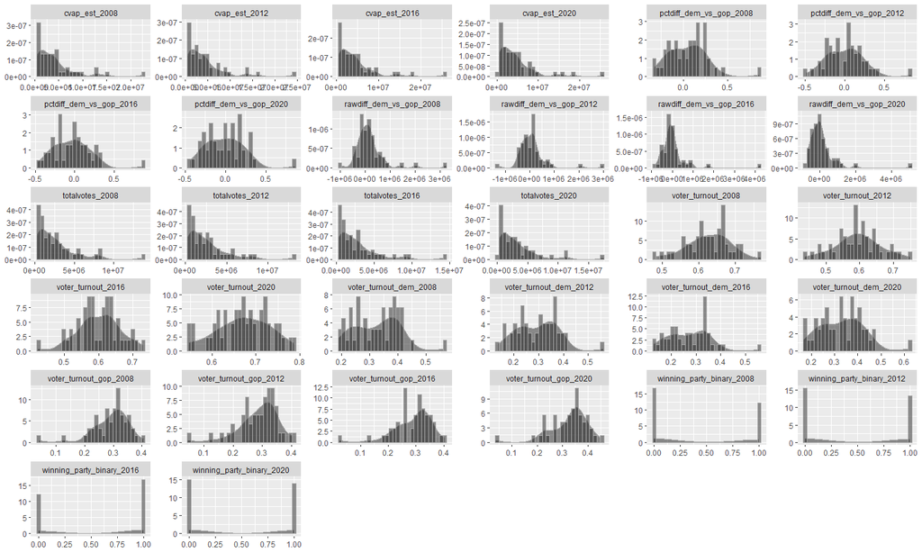

```r
# Histograms
vot_info_fin_pivot %>%
  keep(is.numeric) %>%
  gather() %>%
  ggplot(aes(value)) +
    facet_wrap(~ key, scales = "free") +
    geom_density(fill = "#222222", alpha = 0.5, color = "darkgray") +
    geom_histogram(aes(y=..density..), alpha=0.5, fill = "#222222", color="darkgray", position="identity") +
  theme(axis.title = element_blank())
```

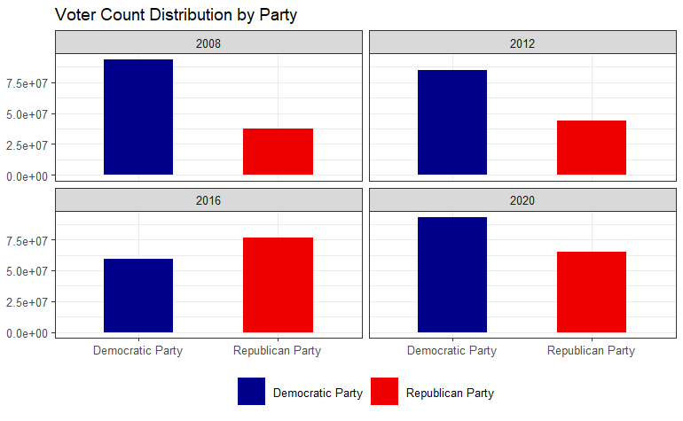

```r
vot_info_fin %>%
  group_by(year, winning_party) %>%
  summarise(count = sum(totalvotes)) %>%
  ggplot(aes(x = winning_party, y = count, fill = winning_party)) +
  # Map fill to winning_party
  scale_fill_manual(values = c("darkblue","red2"))+
  geom_col(width = 0.5) +  #adjust the width as needed
  facet_wrap(~year) +
  theme_bw() + # Setting background as blank
  theme(legend.position = "bottom",
        #legend.position = c(0.11, 0.1), #puts legend inside the plot
        # legend.text = element_text(size = 6), #, family = "Arial"
        legend.key.size = unit(8, "mm"), #changes the size of the legend symbol
        legend.title = element_blank(), #removes legend title
        legend.spacing.x = unit(.25, 'cm'),
        axis.title = element_blank()
        )+
  ggtitle("Voter Count Distribution by Party")
```

## Detect Multicollinearity Using Correlation Matrix

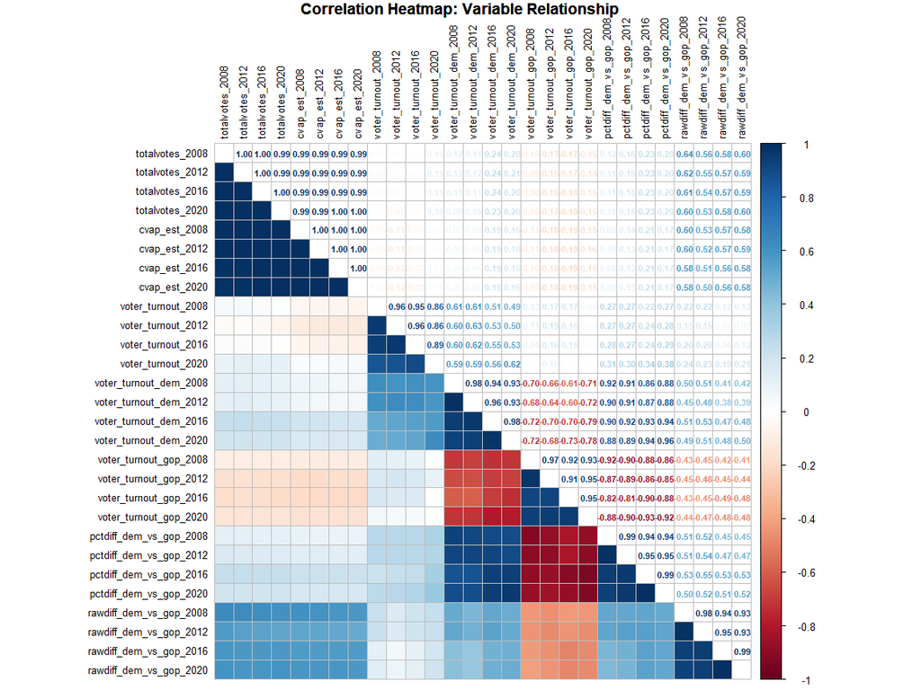

```r
cor_df <- vot_info_fin_pivot %>%
  select(-c(state, starts_with("winning"))) %>%
  keep(is.numeric)

cor_matrix <- cor(cor_df)

# Create a heatmap for the correlation matrix
# Visualize correlation between variables
corrplot.mixed(cor(cor_df %>% keep(is.numeric)),
               tl.col = 'black', tl.pos = 'lt',
               upper = "number", lower="shade",
               shade.col=NA, tl.srt=90,
               number.cex=0.7,tl.cex=0.8,
               title="Correlation Heatmap: Variable Relationship",
               mar = c(0,0,1,0))
```

## Detect Multicollinearity Using VIF

The Variance Inflation Factor (VIF) helps quantify how much multicollinearity exists by showing how much the variance of a coefficient is inflated due to linear dependence with other predictors.

VIF Interpretation:  
VIF = 1: No correlation between the predictor and other variables.  
VIF between 1 and 5: Moderate correlation.  
VIF > 5 (or sometimes > 10): High multicollinearity, and you may want to consider removing this variable.

```r
vif_data <- vif(lm(totalvotes_2020 ~ ., data=cor_df))
# Fit a linear model and calculate VIF
print(vif_data)
```

```
        totalvotes_2008         totalvotes_2012         totalvotes_2016           cvap_est_2008           cvap_est_2012           cvap_est_2016           cvap_est_2020      voter_turnout_2008      voter_turnout_2012      voter_turnout_2016
             12668.3908              12694.3444               7599.7554             148251.5428             359757.1275             134479.5925              29345.9999                731.9125                989.6403                174.6884
     voter_turnout_2020  voter_turnout_dem_2008  voter_turnout_dem_2012  voter_turnout_dem_2016  voter_turnout_dem_2020  voter_turnout_gop_2008  voter_turnout_gop_2012  voter_turnout_gop_2016  voter_turnout_gop_2020 pctdiff_dem_vs_gop_2008
               823.5184               2021.3224               2140.8185               1248.5868               4274.2918               1046.6863               1622.7741               1075.2029                926.9023               1768.3352
pctdiff_dem_vs_gop_2012 pctdiff_dem_vs_gop_2016 pctdiff_dem_vs_gop_2020 rawdiff_dem_vs_gop_2008 rawdiff_dem_vs_gop_2012 rawdiff_dem_vs_gop_2016 rawdiff_dem_vs_gop_2020
              2541.5297               3328.2442               2357.2987                379.9912                427.1657                998.3352                655.8737
```

```r
vif_data %>%
  kable(caption = "Variance Inflation Factor (VIF) Results")%>%
  kable_classic()
```

Variance Inflation Factor (VIF) Results

|  | x |
| --- | --- |
| totalvotes_2008 | 12668.3908 |
| totalvotes_2012 | 12694.3444 |
| totalvotes_2016 | 7599.7554 |
| cvap_est_2008 | 148251.5428 |
| cvap_est_2012 | 359757.1275 |
| cvap_est_2016 | 134479.5925 |
| cvap_est_2020 | 29345.9999 |
| voter_turnout_2008 | 731.9125 |
| voter_turnout_2012 | 989.6403 |
| voter_turnout_2016 | 174.6884 |
| voter_turnout_2020 | 823.5184 |
| voter_turnout_dem_2008 | 2021.3224 |
| voter_turnout_dem_2012 | 2140.8185 |
| voter_turnout_dem_2016 | 1248.5868 |
| voter_turnout_dem_2020 | 4274.2918 |
| voter_turnout_gop_2008 | 1046.6863 |
| voter_turnout_gop_2012 | 1622.7741 |
| voter_turnout_gop_2016 | 1075.2029 |
| voter_turnout_gop_2020 | 926.9023 |
| pctdiff_dem_vs_gop_2008 | 1768.3352 |
| pctdiff_dem_vs_gop_2012 | 2541.5297 |
| pctdiff_dem_vs_gop_2016 | 3328.2442 |
| pctdiff_dem_vs_gop_2020 | 2357.2987 |
| rawdiff_dem_vs_gop_2008 | 379.9912 |
| rawdiff_dem_vs_gop_2012 | 427.1657 |
| rawdiff_dem_vs_gop_2016 | 998.3352 |
| rawdiff_dem_vs_gop_2020 | 655.8737 |

```r
# Convert VIF values to a dataframe for visualization
vif_df <- as.data.frame(vif_data)
vif_df$variables <- rownames(vif_df)
```

# Build Model

Based on the VIF values shown in our exploratory data analysis, it is evident there is high multicollinearity in our data. Multicollinearity, can cause problems in some models (like linear regression) but may not be as critical for tree-based methods like Random Forests. As such, we will build a Random Forest Model.

## Base model

### Train

```r
#train
df_subset <- vot_info_fin_pivot %>%
  select(-c("winning_party_2008",
            "winning_party_2012",
            "winning_party_2020",
            "winning_party_2016")) %>%
  mutate(across(starts_with("winning"), as.factor),
         state = as.factor(state))

# Split the data into training and testing sets (70% train, 30% test)
set.seed(123)  # for reproducibility
train_indices <- sample(seq_len(nrow(df_subset)),
                        size = 0.7 * nrow(df_subset))
train_data <- df_subset[train_indices, ]
test_data <- df_subset[-train_indices, ]

rf_model <- randomForest(winning_party_binary_2020 ~ .,
                         data = train_data, ntree = 500,
                         mtry = 5, importance = TRUE)

# View the model summary
print(rf_model)
```

```
Call:
 randomForest(formula = winning_party_binary_2020 ~ ., data = train_data,      ntree = 500, mtry = 5, importance = TRUE)
               Type of random forest: classification
                     Number of trees: 500
No. of variables tried at each split: 5

        OOB estimate of  error rate: 2.86%
Confusion matrix:
   0  1 class.error
0 16  1  0.05882353
1  0 18  0.00000000
```

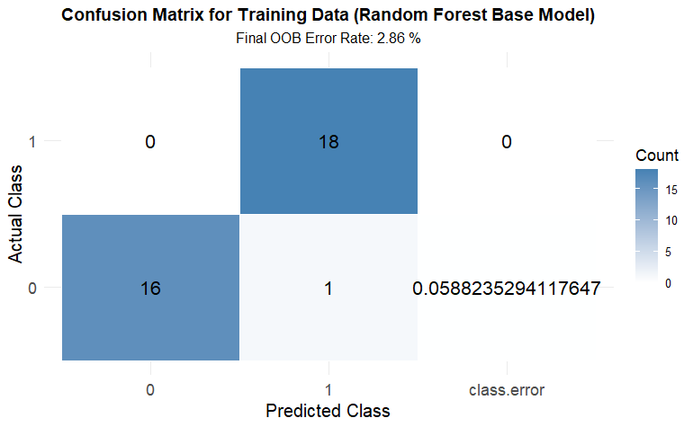

```r
# Extract the confusion matrix from the rf_model
temp_train_conf_matrix <- rf_model$confusion
temp_train_conf_matrix_df <- as.data.frame.matrix(temp_train_conf_matrix)

# Add row names as a new column for proper reshaping
temp_train_conf_matrix_df$Actual <- rownames(temp_train_conf_matrix_df)

# Reshape data for ggplot
temp_train_conf_matrix_long <- melt(temp_train_conf_matrix_df, id.vars = "Actual", variable.name = "Predicted", value.name = "Count")

# Extract and format the OOB error rate
oob_error_rate <- round(tail(rf_model$err.rate[, "OOB"], n = 1) * 100, 2)

# Plot confusion matrix heatmap
ggplot(temp_train_conf_matrix_long, aes(x = Predicted, y = Actual, fill = Count)) +
  geom_tile(color = "white") +
  geom_text(aes(label = Count), color = "black", size = 5) +
  scale_fill_gradient(low = "white", high = "steelblue") +
  labs(
    title = "Confusion Matrix for Training Data (Random Forest Base Model)",
    subtitle = paste("Final OOB Error Rate:", oob_error_rate, "%"),
    x = "Predicted Class",
    y = "Actual Class",
    fill = "Count"
  ) +
  theme_minimal() +
  theme(
    plot.title = element_text(hjust = 0.5, face = "bold"),
    plot.subtitle = element_text(hjust = 0.5),
    axis.text = element_text(size = 12),
    axis.title = element_text(size = 14),
    legend.title = element_text(size = 12)
  )
```

```r
rm(list = ls(pattern = "^temp_train"))
```

This is the out-of-bag (OOB) error estimate, which is an internal error estimate in random forests. In this case, the OOB error rate is 2.86%, meaning that the model predicts strongly on the training data based on the OOB observations. Overall, the model proves to be highly accurate with almost perfect results and minimal overfitting.

### Evaluate

```r
#evaluate
# Predictions on the test data
predictions <- predict(rf_model, test_data)

table(predictions)
```

```
predictions
0 1
8 7
```

```r
# Confusion matrix to evaluate accuracy
conf_matrix <- confusionMatrix(predictions,
                               test_data$winning_party_binary_2020)
print(conf_matrix)
```

```
Confusion Matrix and Statistics

          Reference
Prediction 0 1
         0 8 0
         1 1 6

               Accuracy : 0.9333
                 95% CI : (0.6805, 0.9983)
    No Information Rate : 0.6
    P-Value [Acc > NIR] : 0.005172

                  Kappa : 0.8649

 Mcnemar's Test P-Value : 1.000000

            Sensitivity : 0.8889
            Specificity : 1.0000
         Pos Pred Value : 1.0000
         Neg Pred Value : 0.8571
             Prevalence : 0.6000
         Detection Rate : 0.5333
   Detection Prevalence : 0.5333
      Balanced Accuracy : 0.9444

       'Positive' Class : 0
```

[figure not shown]

```r
# Create confusion matrix data
temp_conf_matrix_data <- matrix(c(8, 0, 1, 6), nrow = 2, byrow = TRUE,
                           dimnames = list("Actual" = c("0", "1"),
                                           "Predicted" = c("0", "1")))
temp_conf_matrix_df <- as.data.frame(as.table(temp_conf_matrix_data))

# Add performance metrics for visualization
temp_conf_accuracy <- 93.33  # Accuracy in percentage
temp_conf_balanced_accuracy <- 94.44  # Balanced accuracy in percentage

# Plot the confusion matrix heatmap
ggplot(temp_conf_matrix_df, aes(x = Predicted, y = Actual, fill = Freq)) +
  geom_tile(color = "white") +
  geom_text(aes(label = Freq), size = 6) +
  scale_fill_gradient(low = "white", high = "steelblue") +
  labs(
    title = "Confusion Matrix for Test Data (Random Forest Base Model)",
    subtitle = paste("Accuracy:", temp_conf_accuracy, "% | Balanced Accuracy:", temp_conf_balanced_accuracy, "%"),
    x = "Predicted Class",
    y = "Actual Class",
    fill = "Count"
  ) +
  theme_minimal() +
  theme(
    plot.title = element_text(hjust = 0.5, face = "bold", size = 14),
    plot.subtitle = element_text(hjust = 0.5, size = 12),
    axis.text = element_text(size = 12),
    axis.title = element_text(size = 14),
    legend.title = element_text(size = 12),
    legend.text = element_text(size = 10)
  )
```

The test data correctly predicts Democrat Party for the 2020 election.

8 samples were correctly classified as 0 (True Negatives). 6 samples were correctly classified as 1 (True Positives). 1 sample was misclassified as 1 instead of 0 (False Positive). 0 samples were misclassified as 0 instead of 1 (False Negative).

Accuracy is the proportion of correct predictions over the total number of predictions: Accuracy =8+6/(8+6+1+0) = 0.9333 or 93.33% This indicates the model correctly classified 93.33% of the test data.

### Checking for Overfitting

```r
rf_cv <- train(winning_party_binary_2020 ~ .,
               data = train_data, method = "rf",
               trControl = trainControl(method = "cv",
                                        number = 10))

print(rf_cv)
```

```
Random Forest

35 samples
32 predictors
 2 classes: '0', '1'

No pre-processing
Resampling: Cross-Validated (10 fold)
Summary of sample sizes: 32, 31, 31, 32, 32, 31, ...
Resampling results across tuning parameters:

  mtry  Accuracy   Kappa
   2    0.9416667  0.89
  41    0.9750000  0.95
  80    0.9750000  0.95

Accuracy was used to select the optimal model using the largest value.
The final value used for the model was mtry = 41.
```

```r
temp_tuning_results <- rf_cv$results[, c("mtry", "Accuracy", "Kappa")]
temp_tuning_results$Accuracy <- round(temp_tuning_results$Accuracy * 100, 2)

# Create the table
temp_tuning_results %>%
  kable(col.names = c("mtry", "Accuracy (%)", "Kappa"),
        caption = "Hyperparameter Tuning Results for Random Forest") %>%
  kable_classic(full_width = FALSE, html_font = "Cambria")
```

Hyperparameter Tuning Results for Random Forest

| mtry | Accuracy (%) | Kappa |
| --- | --- | --- |
| 2 | 94.17 | 0.89 |
| 41 | 97.50 | 0.95 |
| 80 | 97.50 | 0.95 |

If deployed, the model should generalize well given the robustness of Random Forest and the cross-validation methodology used.

### Feature Importance

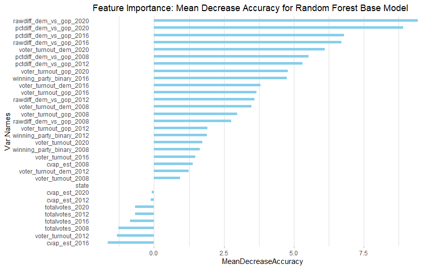

```r
# Variable importance
#varImpPlot(rf_model)
ImpData <- as.data.frame(importance(rf_model))
ImpData$Var.Names <- row.names(ImpData)

#reorder variables based on MeanDecreaseAccuracy to display in descending order
ImpData$Var.Names <-
  factor(ImpData$Var.Names,
         levels = ImpData$Var.Names[order(ImpData$MeanDecreaseAccuracy,
                                          decreasing = FALSE)])

ggplot(ImpData, aes(x=Var.Names, y=MeanDecreaseAccuracy)) +
  geom_segment(aes(x=Var.Names, xend=Var.Names, y=0, yend=MeanDecreaseAccuracy),
               color="skyblue",
               size = 2
               ) +
  #geom_point(aes(size = IncNodePurity), color="steelblue", alpha=1) +
  theme_light() +
  coord_flip() +
  theme(
    legend.position = "bottom",
    panel.grid.major.y = element_blank(),
    panel.border = element_blank(),
    axis.ticks.y = element_blank()
  )+
  ggtitle("Feature Importance: Mean Decrease Accuracy for Random Forest Base Model")
```

Mean Decrease Accuracy (MDA) is another metric used in Random Forest models to measure the importance of attributes. It quantifies how much the model’s predictive accuracy decreases when a particular attribute’s values are randomly permuted. The attributes with the lowest mean decrease accuracy are cvap_est_2016, voter_turnout_2012, totalvotes_2008, totalvotes_2016, and totalvotes_2012.

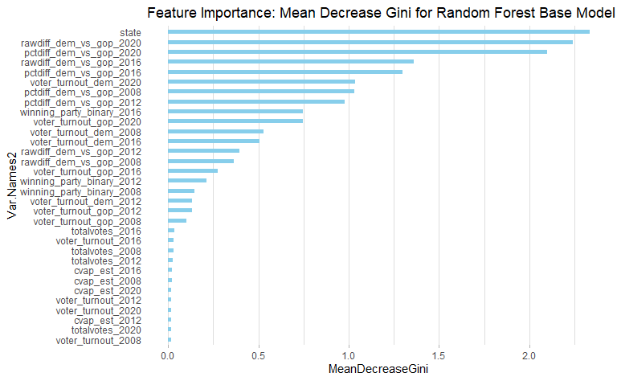

```r
#reorder variables based on MeanDecreaseGini to display in descending order
ImpData$Var.Names2 <- factor(ImpData$Var.Names, levels = ImpData$Var.Names[order(ImpData$MeanDecreaseGini, decreasing = FALSE)])

ggplot(ImpData, aes(x=Var.Names2, y=MeanDecreaseGini)) +
  geom_segment(aes(x=Var.Names2, xend=Var.Names2, y=0, yend=MeanDecreaseGini),
               color="skyblue",
               size = 2) +
  #geom_point(aes(size = IncNodePurity), color="steelblue", alpha=1) +
  theme_light() +
  coord_flip() +
  theme(
    legend.position = "bottom",
    panel.grid.major.y = element_blank(),
    panel.border = element_blank(),
    axis.ticks.y = element_blank()
  )+
  ggtitle("Feature Importance: Mean Decrease Gini for Random Forest Base Model")
```

A high Mean Decrease Gini value for a variable indicates that it is an important attribute in the model. It allows for feature ranking and selection, helping to identify which variables most significantly impact the model’s output. In our model, the top 5 attributes are state, rawdiff_dem_vs_gop_2020, pctdiff_dem_vs_gop_2020, rawdiff_dem_vs_gop_2016, pctdiff_dem_vs_gop_2016.

## Demographic data

```r
# To obtain data for the 2008 population from the American Community
# Survey (ACS), you should use the 2006-2008 ACS 3-Year Estimates.
# This dataset aggregates data collected over those three years,
#  providing insights for the population during that period. 5
# year ACS data unavailable for 2008. 3 year ACS data was discontinued
# after 2009.

#load 2008 data using API
ed_attain2008 <- get_acs(
  geography = "county",
  variables = c(paste0("B15001_00",
                       seq(01,09),"E"),
                paste0("B15001_0",
                       seq(10,83),"E")),
  year = 2008,
  survey = "acs3",
  cache_table = TRUE) %>%
  mutate(year=2008)

#2012 data and onward uses the 5 year ACS data
#load 2012 data using API
ed_attain2012 <- get_acs(
  geography = "county",
  variables = c(paste0("B15001_00",
                       seq(01,09),"E"),
                paste0("B15001_0",
                       seq(10,83),"E")),
  year = 2012,
  survey = "acs5",
  cache_table = TRUE) %>%
  mutate(year=2012)

#load 2016 data using API
ed_attain2016 <- get_acs(
  geography = "county",
  variables = c(paste0("B15001_00",
                       seq(01,09),"E"),
                paste0("B15001_0",
                       seq(10,83),"E")),
  year = 2016,
  survey = "acs5",
  cache_table = TRUE) %>%
  mutate(year=2016)

#load 2020 data using API
ed_attain2020 <- get_acs(
  geography = "county",
  variables = c(paste0("B15001_00",
                       seq(01,09),"E"),
                paste0("B15001_0",
                       seq(10,83),"E")),
  year = 2020,
  survey = "acs5",
  cache_table = TRUE) %>%
  mutate(year=2020)
```

#### Get column names

```r
#check column names
#get column names 2008
url08 <- "https://api.census.gov/data/2008/acs/acs3/groups/B15001.html"

webpage08 <- read_html(url08)

table08 <- webpage08 %>%
  html_node("table") %>%  # Adjust the selector if necessary
  html_table() %>%
  select(c("Name","Label","Concept","Required","Attributes",
           "Limit","Predicate Type","Group"))

filteredtable08 <- table08 %>%
  # filter(!is.na(Name) & Name != "") %>%
  # Remove rows with NA or empty names
  filter(Name %in% c(paste0("B15001_00", seq(01,09),"E"),
                     paste0("B15001_0", seq(10,83),"E")))
# %>%
#    mutate(Label = str_replace_all(Label,", GED, or alternative",
# ' (includes equivalency)'))

#get column names  2012
url12 <- "https://api.census.gov/data/2012/acs/acs5/groups/B15001.html"

webpage12 <- read_html(url12)

table12 <- webpage12 %>%
  html_node("table") %>%  # Adjust the selector if necessary
  html_table() %>%
  select(c("Name","Label","Concept","Required","Attributes",
           "Limit","Predicate Type","Group"))

filteredtable12 <- table12 %>%
  # filter(!is.na(Name) & Name != "") %>%
  # Remove rows with NA or empty names
  filter(Name %in% c(paste0("B15001_00", seq(01,09),"E"),
                     paste0("B15001_0", seq(10,83),"E")))
# %>%
#    mutate(Label = str_replace_all(Label,", GED, or alternative",
#' (includes equivalency)'))

#get column names 2016
url16 <- "https://api.census.gov/data/2016/acs/acs5/groups/B15001.html"

webpage16 <- read_html(url16)

table16 <- webpage16 %>%
  html_node("table") %>%  # Adjust the selector if necessary
  html_table() %>%
  select(c("Name","Label","Concept","Required","Attributes",
           "Limit","Predicate Type","Group"))

filteredtable16 <- table16 %>%
  # filter(!is.na(Name) & Name != "") %>%  # Remove rows with NA or empty names
  filter(Name %in% c(paste0("B15001_00", seq(01,09),"E"),
                     paste0("B15001_0", seq(10,83),"E")))

#get columnn names 2020
url20 <- "https://api.census.gov/data/2020/acs/acs5/groups/B15001.html"

webpage20 <- read_html(url20)

table20 <- webpage20 %>%
  html_node("table") %>%  # Adjust the selector if necessary
  html_table() %>%
  select(c("Name","Label","Concept","Required","Attributes",
           "Limit","Predicate Type","Group"))

filteredtable20 <- table20 %>%
  # filter(!is.na(Name) & Name != "") %>%  # Remove rows with NA or empty names
  filter(Name %in% c(paste0("B15001_00", seq(01,09),"E"),
                     paste0("B15001_0", seq(10,83),"E"))) %>%
  mutate(Label = str_replace_all(Label,":",""))
```

```r
#update the mismatches
filteredtable08 <- filteredtable08 %>%
   mutate(Label = str_replace_all(Label,", GED, or alternative",
                                  ' (includes equivalency)'))

filteredtable12 <- filteredtable12 %>%
  mutate(Label = str_replace_all(Label,", GED, or alternative",
                                 ' (includes equivalency)'))
```

All column names are the same across all 4 election year Educational Attainment data.

#### Combine and merge education data

```r
ed_attain <- rbind(ed_attain2008, ed_attain2012, ed_attain2016, ed_attain2020)
```

```r
ed_colnames <- filteredtable20 %>%
  mutate(Name = str_replace_all(Name,"E","")) %>%
  select(c(Name, Label))

table(sort(unique(ed_colnames$Name))==sort(unique(ed_attain$variable)))
```

```
TRUE
  83
```

```r
ed_attain2a <- left_join(ed_attain, ed_colnames, by = c("variable"="Name"))

glimpse(ed_attain2a)
```

```
Rows: 958,567
Columns: 7
$ GEOID    <chr> "01001", "01001", "01001", "01001", "01001", "01001", "01001", "01001", "01001", "01001", "01001", "01001", "01001", "01001", "01001", "01001", "01001", "01001", "01001", "01001", "01001", "01001", "01001", "01001", "01001", "01001", "0100…
$ NAME     <chr> "Autauga County, Alabama", "Autauga County, Alabama", "Autauga County, Alabama", "Autauga County, Alabama", "Autauga County, Alabama", "Autauga County, Alabama", "Autauga County, Alabama", "Autauga County, Alabama", "Autauga County, Alabam…
$ variable <chr> "B15001_001", "B15001_002", "B15001_003", "B15001_004", "B15001_005", "B15001_006", "B15001_007", "B15001_008", "B15001_009", "B15001_010", "B15001_011", "B15001_012", "B15001_013", "B15001_014", "B15001_015", "B15001_016", "B15001_017", "…
$ estimate <dbl> 36493, 17387, 2160, 0, 543, 913, 567, 14, 123, 0, 3157, 64, 332, 1677, 550, 73, 389, 72, 3646, 178, 362, 1174, 734, 182, 665, 351, 6066, 272, 555, 1932, 1198, 504, 1103, 502, 2358, 269, 256, 944, 393, 69, 180, 247, 19106, 2284, 44, 415, 81…
$ moe      <dbl> 132, 127, 182, 154, 260, 286, 177, 24, 89, 154, 244, 76, 222, 332, 161, 68, 197, 56, 185, 115, 163, 230, 196, 88, 191, 140, 74, 190, 175, 334, 225, 173, 203, 191, 38, 119, 133, 201, 130, 57, 91, 112, 106, 122, 68, 174, 249, 213, 89, 167, 1…
$ year     <dbl> 2008, 2008, 2008, 2008, 2008, 2008, 2008, 2008, 2008, 2008, 2008, 2008, 2008, 2008, 2008, 2008, 2008, 2008, 2008, 2008, 2008, 2008, 2008, 2008, 2008, 2008, 2008, 2008, 2008, 2008, 2008, 2008, 2008, 2008, 2008, 2008, 2008, 2008, 2008, 2008,…
$ Label    <chr> "Estimate!!Total", "Estimate!!Total!!Male", "Estimate!!Total!!Male!!18 to 24 years", "Estimate!!Total!!Male!!18 to 24 years!!Less than 9th grade", "Estimate!!Total!!Male!!18 to 24 years!!9th to 12th grade, no diploma", "Estimate!!Total!!Ma…
```

```r
#identify empty and NA values
colSums(ed_attain2a == "" | is.na(ed_attain2a))
```

```
   GEOID     NAME variable estimate      moe     year    Label
       0        0        0        0     8584        0        0
```

#### Clean and reshape data

```r
# voteFIPS <- unique(voting_info_final_pivot$FIPS)
demoFIPS <- unique(ed_attain2a$GEOID)

ed_attain2 <- ed_attain2a %>%
  filter(!GEOID %in% setdiff(demoFIPS, ls_FIPS)) %>%
  #keep only the fips we have in the voting dataset
  separate(col="NAME", into=c("county", "state"), sep=",") %>%
  mutate(county = str_remove(county, " County"),
         county = if_else(county == "Doña Ana", "Dona Ana", county)
         )

ed_attain3 <- ed_attain2 %>%
  group_by(state, year, variable, Label) %>%
  summarise(estimate = sum(estimate),
            moe = sum(moe)) %>%
  mutate(Label2 = Label) %>%
  separate(Label2, into = c("type","value","gender", "age_group",
                            "education"), sep = "!!")
length(unique(ed_attain3$GEOID))
```

```
[1] 0
```

```r
# edcountystate <- ed_attain3 %>%
#   select(GEOID,county, state) %>%
#   distinct(GEOID,county,state) %>%
#   group_by(GEOID) %>%
#   summarise(count=n())
```

```r
head(ed_attain3, 10)
```

| state | year | variable | Label | estimate | moe | type | value | gender | age_group | education |
| --- | --- | --- | --- | --- | --- | --- | --- | --- | --- | --- |
| Alabama | 2008 | B15001_001 | Estimate!!Total | 3312158 | 3241 | Estimate | Total | NA | NA | NA |
| Alabama | 2008 | B15001_002 | Estimate!!Total!!Male | 1575413 | 4947 | Estimate | Total | Male | NA | NA |
| Alabama | 2008 | B15001_003 | Estimate!!Total!!Male!!18 to 24 years | 216719 | 7405 | Estimate | Total | Male | 18 to 24 years | NA |
| Alabama | 2008 | B15001_004 | Estimate!!Total!!Male!!18 to 24 years!!Less than 9th grade | 5635 | 5162 | Estimate | Total | Male | 18 to 24 years | Less than 9th grade |
| Alabama | 2008 | B15001_005 | Estimate!!Total!!Male!!18 to 24 years!!9th to 12th grade, no diploma | 43862 | 12926 | Estimate | Total | Male | 18 to 24 years | 9th to 12th grade, no diploma |
| Alabama | 2008 | B15001_006 | Estimate!!Total!!Male!!18 to 24 years!!High school graduate (includes equivalency) | 74290 | 15113 | Estimate | Total | Male | 18 to 24 years | High school graduate (includes equivalency) |
| Alabama | 2008 | B15001_007 | Estimate!!Total!!Male!!18 to 24 years!!Some college, no degree | 72890 | 15034 | Estimate | Total | Male | 18 to 24 years | Some college, no degree |
| Alabama | 2008 | B15001_008 | Estimate!!Total!!Male!!18 to 24 years!!Associate's degree | 7478 | 5801 | Estimate | Total | Male | 18 to 24 years | Associate's degree |
| Alabama | 2008 | B15001_009 | Estimate!!Total!!Male!!18 to 24 years!!Bachelor's degree | 11740 | 6353 | Estimate | Total | Male | 18 to 24 years | Bachelor's degree |
| Alabama | 2008 | B15001_010 | Estimate!!Total!!Male!!18 to 24 years!!Graduate or professional degree | 824 | 6330 | Estimate | Total | Male | 18 to 24 years | Graduate or professional degree |

```r
#identify empty and NA values
colSums(ed_attain3 == "" | is.na(ed_attain3))
```

```
    state      year  variable     Label  estimate       moe      type     value    gender age_group education
        0         0         0         0         0      1065         0         0       200       600      2600
```

```r
ed_attain3_na <- ed_attain3 %>%
  filter(is.na(gender) | is.na(age_group) |
           is.na(education)) #is.na(gender) |

ed_attain3_na %>%
  count(variable, Label)
```

| state | year | variable | Label | n |
| --- | --- | --- | --- | --- |
| Alabama | 2008 | B15001_001 | Estimate!!Total | 1 |
| Alabama | 2008 | B15001_002 | Estimate!!Total!!Male | 1 |
| Alabama | 2008 | B15001_003 | Estimate!!Total!!Male!!18 to 24 years | 1 |
| Alabama | 2008 | B15001_011 | Estimate!!Total!!Male!!25 to 34 years | 1 |
| Alabama | 2008 | B15001_019 | Estimate!!Total!!Male!!35 to 44 years | 1 |
| Alabama | 2008 | B15001_027 | Estimate!!Total!!Male!!45 to 64 years | 1 |
| Alabama | 2008 | B15001_035 | Estimate!!Total!!Male!!65 years and over | 1 |
| Alabama | 2008 | B15001_043 | Estimate!!Total!!Female | 1 |
| Alabama | 2008 | B15001_044 | Estimate!!Total!!Female!!18 to 24 years | 1 |
| Alabama | 2008 | B15001_052 | Estimate!!Total!!Female!!25 to 34 years | 1 |

[output cut: 990 more lines]

```r
unique(ed_attain3_na$variable)
```

```
 [1] "B15001_001" "B15001_002" "B15001_003" "B15001_011" "B15001_019" "B15001_027" "B15001_035" "B15001_043" "B15001_044" "B15001_052" "B15001_060" "B15001_068" "B15001_076"
```

```r
#total county population
tot_pop <- ed_attain3 %>%
  filter(is.na(gender)) %>%
  select(state,  estimate, year, value)
#value is the column name that will be used to spread/pivot_wider

#male/female county population
gen <- ed_attain3 %>%
  filter(is.na(age_group), !is.na(gender)) %>%
  select(state,  estimate, year, gender)
#gender and age grp population
age_gen_pop <- ed_attain3_na %>%
  filter(!is.na(age_group)) %>%
  select(state,  estimate, year, gender, age_group)
#gender, age, education
ed_pop <- ed_attain3 %>%
  filter(!is.na(education)) %>%
  select(state, estimate, year, gender, age_group, education)
#age, education
age <- ed_pop %>%
  group_by(state,  year, age_group) %>%
  summarise(estimate = sum(estimate))
#gender, education
ed_pop2 <- ed_pop %>%
  group_by(state,  year, gender, education) %>%
  summarise(estimate = sum(estimate))
#age, education
ed_pop3 <- ed_pop %>%
  group_by(state,  year, age_group,  education) %>%
  summarise(estimate = sum(estimate))
#education
ed_pop4 <- ed_pop %>%
  group_by(state,  year, education) %>%
  summarise(estimate = sum(estimate))
```

### Age, Gender, Education

```r
#need to spread/pivot_wider and then merge with main dataset for modelling
#age
age <- ed_pop %>%
  group_by(state,  year, age_group) %>%
  summarise(estimate = sum(estimate))
#gender
gen <- ed_attain3 %>%
  filter(is.na(age_group), !is.na(gender)) %>%
  select(state,  estimate, year, gender)
#education level
edu <- ed_pop %>%
  group_by(state,  year, education) %>%
  summarise(estimate = sum(estimate))
```

```r
#age pivoted
age2 <- age %>%
  pivot_wider(id_cols = c(state),
              names_from = c(year,age_group),
              values_from = estimate)

colSums(age2 == "" | is.na(age2))
```

```
                 state    2008_18 to 24 years    2008_25 to 34 years    2008_35 to 44 years    2008_45 to 64 years 2008_65 years and over    2012_18 to 24 years    2012_25 to 34 years    2012_35 to 44 years    2012_45 to 64 years 2012_65 years and over
                     0                      0                      0                      0                      0                      0                      0                      0                      0                      0                      0
   2016_18 to 24 years    2016_25 to 34 years    2016_35 to 44 years    2016_45 to 64 years 2016_65 years and over    2020_18 to 24 years    2020_25 to 34 years    2020_35 to 44 years    2020_45 to 64 years 2020_65 years and over
                     0                      0                      0                      0                      0                      0                      0                      0                      0                      0
```

```r
#gender pivoted
gen2 <- gen %>%
  pivot_wider(id_cols = c(state),
              names_from = c(year, gender),
              values_from = estimate)

colSums(gen2 == "" | is.na(gen2))
```

```
      state   2008_Male 2008_Female   2012_Male 2012_Female   2016_Male 2016_Female   2020_Male 2020_Female
          0           0           0           0           0           0           0           0           0
```

```r
#edu pivoted
edu2 <- edu %>%
  pivot_wider(id_cols = c(state),
              names_from = c(year, education),
              values_from = estimate)

colSums(edu2 == "" | is.na(edu2))
```

```
                                           state               2008_9th to 12th grade, no diploma                          2008_Associate's degree                           2008_Bachelor's degree             2008_Graduate or professional degree
                                               0                                                0                                                0                                                0                                                0
2008_High school graduate (includes equivalency)                         2008_Less than 9th grade                     2008_Some college, no degree               2012_9th to 12th grade, no diploma                          2012_Associate's degree
                                               0                                                0                                                0                                                0                                                0
                          2012_Bachelor's degree             2012_Graduate or professional degree 2012_High school graduate (includes equivalency)                         2012_Less than 9th grade                     2012_Some college, no degree
                                               0                                                0                                                0                                                0                                                0
              2016_9th to 12th grade, no diploma                          2016_Associate's degree                           2016_Bachelor's degree             2016_Graduate or professional degree 2016_High school graduate (includes equivalency)
                                               0                                                0                                                0                                                0                                                0
                        2016_Less than 9th grade                     2016_Some college, no degree               2020_9th to 12th grade, no diploma                          2020_Associate's degree                           2020_Bachelor's degree
                                               0                                                0                                                0                                                0                                                0
            2020_Graduate or professional degree 2020_High school graduate (includes equivalency)                         2020_Less than 9th grade                     2020_Some college, no degree
                                               0                                                0                                                0                                                0
```

```r
age2 <- age2 %>%
  select(-starts_with("2008"))

gen2 <- gen2 %>%
  select(-starts_with("2008"))

edu2 <- edu2 %>%
  select(-starts_with("2008"))
```

```r
dem0 <- left_join(age2, gen2, by = c("state"))

dem <- left_join(dem0, edu2, by = c("state")) %>%
  ungroup()

#check dimensions, there is an extra state now
dim(dem)
```

```
[1] 50 43
```

```r
#na / empty cell check
colSums(dem == "" | is.na(dem))
```

```
                                           state                              2012_18 to 24 years                              2012_25 to 34 years                              2012_35 to 44 years                              2012_45 to 64 years
                                               0                                                0                                                0                                                0                                                0
                          2012_65 years and over                              2016_18 to 24 years                              2016_25 to 34 years                              2016_35 to 44 years                              2016_45 to 64 years
                                               0                                                0                                                0                                                0                                                0
                          2016_65 years and over                              2020_18 to 24 years                              2020_25 to 34 years                              2020_35 to 44 years                              2020_45 to 64 years
                                               0                                                0                                                0                                                0                                                0
                          2020_65 years and over                                        2012_Male                                      2012_Female                                        2016_Male                                      2016_Female
                                               0                                                0                                                0                                                0                                                0
                                       2020_Male                                      2020_Female               2012_9th to 12th grade, no diploma                          2012_Associate's degree                           2012_Bachelor's degree
                                               0                                                0                                                0                                                0                                                0
            2012_Graduate or professional degree 2012_High school graduate (includes equivalency)                         2012_Less than 9th grade                     2012_Some college, no degree               2016_9th to 12th grade, no diploma
                                               0                                                0                                                0                                                0                                                0
                         2016_Associate's degree                           2016_Bachelor's degree             2016_Graduate or professional degree 2016_High school graduate (includes equivalency)                         2016_Less than 9th grade
                                               0                                                0                                                0                                                0                                                0
                    2016_Some college, no degree               2020_9th to 12th grade, no diploma                          2020_Associate's degree                           2020_Bachelor's degree             2020_Graduate or professional degree
                                               0                                                0                                                0                                                0                                                0
2020_High school graduate (includes equivalency)                         2020_Less than 9th grade                     2020_Some college, no degree
                                               0                                                0                                                0
```

```r
#check for dupe, no dupe, but Puerto Rico needs to be filtered out
unique(dem$state)
```

```
 [1] " Alabama"              " Arizona"              " Arkansas"             " California"           " Colorado"             " Connecticut"          " Delaware"             " District of Columbia" " Florida"              " Georgia"
[11] " Hawaii"               " Idaho"                " Illinois"             " Indiana"              " Iowa"                 " Kansas"               " Kentucky"             " Louisiana"            " Maine"                " Maryland"
[21] " Massachusetts"        " Michigan"             " Minnesota"            " Mississippi"          " Missouri"             " Montana"              " Nebraska"             " Nevada"               " New Hampshire"        " New Jersey"
[31] " New Mexico"           " New York"             " North Carolina"       " North Dakota"         " Ohio"                 " Oklahoma"             " Oregon"               " Pennsylvania"         " Rhode Island"         " South Carolina"
[41] " South Dakota"         " Tennessee"            " Texas"                " Utah"                 " Vermont"              " Virginia"             " Washington"           " West Virginia"        " Wisconsin"            " Wyoming"
```

#### Clean up

```r
dem <- dem %>%
  filter(!str_detect(state, "Puerto Rico")) %>%
  mutate(state = trimws(state, which="both"))

vot_info_fin_pivot <- vot_info_fin_pivot %>%
  mutate(state = str_to_title(state))
```

### Merge with model data

```r
model_data <- left_join(vot_info_fin_pivot, dem, join_by(state == state))

dim(model_data)
```

```
[1] 50 79
```

```r
colSums(model_data == "" | is.na(model_data))
```

```
                                           state                                  totalvotes_2008                                  totalvotes_2012                                  totalvotes_2016                                  totalvotes_2020
                                               0                                                0                                                0                                                0                                                0
                                   cvap_est_2008                                    cvap_est_2012                                    cvap_est_2016                                    cvap_est_2020                               voter_turnout_2008
                                               0                                                0                                                0                                                0                                                0
                              voter_turnout_2012                               voter_turnout_2016                               voter_turnout_2020                           voter_turnout_dem_2008                           voter_turnout_dem_2012
                                               0                                                0                                                0                                                0                                                0
                          voter_turnout_dem_2016                           voter_turnout_dem_2020                           voter_turnout_gop_2008                           voter_turnout_gop_2012                           voter_turnout_gop_2016
                                               0                                                0                                                0                                                0                                                0
                          voter_turnout_gop_2020                          pctdiff_dem_vs_gop_2008                          pctdiff_dem_vs_gop_2012                          pctdiff_dem_vs_gop_2016                          pctdiff_dem_vs_gop_2020
                                               0                                                0                                                0                                                0                                                0
                         rawdiff_dem_vs_gop_2008                          rawdiff_dem_vs_gop_2012                          rawdiff_dem_vs_gop_2016                          rawdiff_dem_vs_gop_2020                               winning_party_2008
                                               0                                                0                                                0                                                0                                                0
                              winning_party_2012                               winning_party_2016                               winning_party_2020                        winning_party_binary_2008                        winning_party_binary_2012
                                               0                                                0                                                0                                                0                                                0
                       winning_party_binary_2016                        winning_party_binary_2020                              2012_18 to 24 years                              2012_25 to 34 years                              2012_35 to 44 years
                                               0                                                0                                                1                                                1                                                1
                             2012_45 to 64 years                           2012_65 years and over                              2016_18 to 24 years                              2016_25 to 34 years                              2016_35 to 44 years
                                               1                                                1                                                1                                                1                                                1
                             2016_45 to 64 years                           2016_65 years and over                              2020_18 to 24 years                              2020_25 to 34 years                              2020_35 to 44 years
                                               1                                                1                                                1                                                1                                                1
                             2020_45 to 64 years                           2020_65 years and over                                        2012_Male                                      2012_Female                                        2016_Male
```

[output cut: 11 more lines]

```r
model_data2 <- model_data %>%
  drop_na() %>%
  janitor::clean_names()

dim(model_data2)
```

```
[1] 49 79
```

```r
# glimpse(model_data2)
```

| Variable_Name | Description | Data_Type |
| --- | --- | --- |
| state | State name or abbreviation. | Character |
| totalvotes_2008 | Total votes cast in 2008. | Numeric |
| totalvotes_2012 | Total votes cast in 2012. | Numeric |
| totalvotes_2016 | Total votes cast in 2016. | Numeric |
| totalvotes_2020 | Total votes cast in 2020. | Numeric |
| cvap_est_2008 | Citizen voting age population estimate for 2008. | Numeric |
| cvap_est_2012 | Citizen voting age population estimate for 2012. | Numeric |
| cvap_est_2016 | Citizen voting age population estimate for 2016. | Numeric |
| cvap_est_2020 | Citizen voting age population estimate for 2020. | Numeric |
| voter_turnout_2008 | Voter turnout as a proportion of CVAP in 2008. | Numeric |
| voter_turnout_2012 | Voter turnout as a proportion of CVAP in 2012. | Numeric |
| voter_turnout_2016 | Voter turnout as a proportion of CVAP in 2016. | Numeric |
| voter_turnout_2020 | Voter turnout as a proportion of CVAP in 2020. | Numeric |
| voter_turnout_dem_2008 | Democratic voter turnout as a proportion of CVAP in 2008. | Numeric |
| voter_turnout_dem_2012 | Democratic voter turnout as a proportion of CVAP in 2012. | Numeric |
| voter_turnout_dem_2016 | Democratic voter turnout as a proportion of CVAP in 2016. | Numeric |
| voter_turnout_dem_2020 | Democratic voter turnout as a proportion of CVAP in 2020. | Numeric |
| voter_turnout_gop_2008 | Republican voter turnout as a proportion of CVAP in 2008. | Numeric |
| voter_turnout_gop_2012 | Republican voter turnout as a proportion of CVAP in 2012. | Numeric |
| voter_turnout_gop_2016 | Republican voter turnout as a proportion of CVAP in 2016. | Numeric |
| voter_turnout_gop_2020 | Republican voter turnout as a proportion of CVAP in 2020. | Numeric |
| pctdiff_dem_vs_gop_2008 | Percentage difference between Democratic and Republican votes in 2008. | Numeric |
| pctdiff_dem_vs_gop_2012 | Percentage difference between Democratic and Republican votes in 2012. | Numeric |
| pctdiff_dem_vs_gop_2016 | Percentage difference between Democratic and Republican votes in 2016. | Numeric |
| pctdiff_dem_vs_gop_2020 | Percentage difference between Democratic and Republican votes in 2020. | Numeric |
| rawdiff_dem_vs_gop_2008 | Raw vote difference between Democratic and Republican votes in 2008. | Numeric |
| rawdiff_dem_vs_gop_2012 | Raw vote difference between Democratic and Republican votes in 2012. | Numeric |
| rawdiff_dem_vs_gop_2016 | Raw vote difference between Democratic and Republican votes in 2016. | Numeric |
| rawdiff_dem_vs_gop_2020 | Raw vote difference between Democratic and Republican votes in 2020. | Numeric |
| winning_party_2008 | Party with the majority of votes in 2008. | Character |
| winning_party_2012 | Party with the majority of votes in 2012. | Character |
| winning_party_2016 | Party with the majority of votes in 2016. | Character |
| winning_party_2020 | Party with the majority of votes in 2020. | Character |

#Build Second Model

### Train

```r
#train
df_subset2 <- model_data2 %>%
  select(-c("winning_party_2008", "winning_party_2012", "winning_party_2020", "winning_party_2016")) %>%
  mutate(across(starts_with("winning"), as.factor),
         state = as.factor(state))

# Split the data into training and testing sets (70% train, 30% test)
set.seed(123)  # for reproducibility
train_indices2 <- sample(seq_len(nrow(df_subset2)),
                         size = 0.7 * nrow(df_subset2))
train_data2 <- df_subset2[train_indices2, ]
test_data2 <- df_subset2[-train_indices2, ]

rf_model2 <- randomForest(winning_party_binary_2020 ~ .,
                          data = train_data2,
                          ntree = 500,
                          mtry = 5,
                          importance = TRUE)

# View the model summary
print(rf_model2)
```

```
Call:
 randomForest(formula = winning_party_binary_2020 ~ ., data = train_data2,      ntree = 500, mtry = 5, importance = TRUE)
               Type of random forest: classification
                     Number of trees: 500
No. of variables tried at each split: 5

        OOB estimate of  error rate: 5.88%
Confusion matrix:
   0  1 class.error
0 15  1  0.06250000
1  1 17  0.05555556
```

True 0 (15): 15 instances of class 0 were correctly classified.

False 0 (1): 1 instance was incorrectly classified as 0.

True 1 (17): 17 instances of class 1 were correctly classified.

False 1 (1): Only 1 instance was incorrectly classified as 1.

[figure not shown]

```r
# Extract the confusion matrix from the rf_model
temp_train_conf_matrix <- rf_model2$confusion
temp_train_conf_matrix_df <- as.data.frame.matrix(temp_train_conf_matrix)

# Add row names as a new column for proper reshaping
temp_train_conf_matrix_df$Actual <- rownames(temp_train_conf_matrix_df)

# Reshape data for ggplot
temp_train_conf_matrix_long <- melt(temp_train_conf_matrix_df, id.vars = "Actual", variable.name = "Predicted", value.name = "Count")

# Extract and format the OOB error rate
oob_error_rate <- round(tail(rf_model$err.rate[, "OOB"], n = 1) * 100, 2)

# Plot confusion matrix heatmap
ggplot(temp_train_conf_matrix_long, aes(x = Predicted, y = Actual, fill = Count)) +
  geom_tile(color = "white") +
  geom_text(aes(label = Count), color = "black", size = 5) +
  scale_fill_gradient(low = "white", high = "steelblue") +
  labs(
    title = "Confusion Matrix for Training Data (Random Forest Final Model)",
    subtitle = paste("Final OOB Error Rate:", oob_error_rate, "%"),
    x = "Predicted Class",
    y = "Actual Class",
    fill = "Count"
  ) +
  theme_minimal() +
  theme(
    plot.title = element_text(hjust = 0.5, face = "bold"),
    plot.subtitle = element_text(hjust = 0.5),
    axis.text = element_text(size = 12),
    axis.title = element_text(size = 14),
    legend.title = element_text(size = 12)
  )
```

### Evaluate

```r
#evaluate
# Predictions on the test data
predictions2 <- predict(rf_model2, test_data2)

#0= dem, 1=rep
table(predictions2)
```

```
predictions2
0 1
8 7
```

```r
# Confusion matrix to evaluate accuracy
conf_matrix2 <- confusionMatrix(predictions2, test_data2$winning_party_binary_2020)
print(conf_matrix2)
```

```
Confusion Matrix and Statistics

          Reference
Prediction 0 1
         0 8 0
         1 1 6

               Accuracy : 0.9333
                 95% CI : (0.6805, 0.9983)
    No Information Rate : 0.6
    P-Value [Acc > NIR] : 0.005172

                  Kappa : 0.8649

 Mcnemar's Test P-Value : 1.000000

            Sensitivity : 0.8889
            Specificity : 1.0000
         Pos Pred Value : 1.0000
         Neg Pred Value : 0.8571
             Prevalence : 0.6000
         Detection Rate : 0.5333
   Detection Prevalence : 0.5333
      Balanced Accuracy : 0.9444

       'Positive' Class : 0
```

[figure not shown]

```r
# Create confusion matrix data
temp_conf_matrix_data <- matrix(c(8, 0, 1, 6), nrow = 2, byrow = TRUE,
                           dimnames = list("Actual" = c("0", "1"),
                                           "Predicted" = c("0", "1")))
temp_conf_matrix_df <- as.data.frame(as.table(temp_conf_matrix_data))

# Add performance metrics for visualization
temp_conf_accuracy <- 93.33  # Accuracy in percentage
temp_conf_balanced_accuracy <- 94.44  # Balanced accuracy in percentage

# Plot the confusion matrix heatmap
ggplot(temp_conf_matrix_df, aes(x = Predicted, y = Actual, fill = Freq)) +
  geom_tile(color = "white") +
  geom_text(aes(label = Freq), size = 6) +
  scale_fill_gradient(low = "white", high = "steelblue") +
  labs(
    title = "Confusion Matrix for Test Data (Random Forest Final Model)",
    subtitle = paste("Accuracy:", temp_conf_accuracy, "% | Balanced Accuracy:", temp_conf_balanced_accuracy, "%"),
    x = "Predicted Class",
    y = "Actual Class",
    fill = "Count"
  ) +
  theme_minimal() +
  theme(
    plot.title = element_text(hjust = 0.5, face = "bold", size = 14),
    plot.subtitle = element_text(hjust = 0.5, size = 12),
    axis.text = element_text(size = 12),
    axis.title = element_text(size = 14),
    legend.title = element_text(size = 12),
    legend.text = element_text(size = 10)
  )
```

### Checking for Overfitting

```r
rf_cv2 <- train(winning_party_binary_2020 ~ .,
                data = train_data2,
                method = "rf",
                trControl = trainControl(method = "cv", number = 10))

print(rf_cv2)
```

```
Random Forest

34 samples
74 predictors
 2 classes: '0', '1'

No pre-processing
Resampling: Cross-Validated (10 fold)
Summary of sample sizes: 30, 30, 30, 31, 31, 31, ...
Resampling results across tuning parameters:

  mtry  Accuracy   Kappa
    2   0.8500000  0.68
   61   0.9333333  0.88
  121   0.9333333  0.88

Accuracy was used to select the optimal model using the largest value.
The final value used for the model was mtry = 61.
```

### Feature Importance

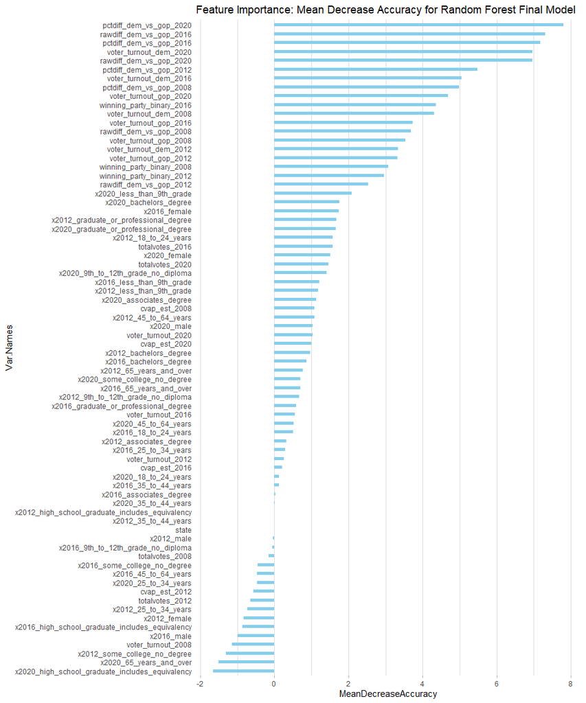

```r
# Variable importance

ImpData2 <- as.data.frame(importance(rf_model2))
ImpData2$Var.Names <- row.names(ImpData2)

#reorder variables based on MeanDecreaseAccuracy to display in descending order
ImpData2$Var.Names <- factor(ImpData2$Var.Names, levels = ImpData2$Var.Names[order(ImpData2$MeanDecreaseAccuracy, decreasing = FALSE)])

ggplot(ImpData2, aes(x=Var.Names, y=MeanDecreaseAccuracy)) +
  geom_segment(aes(x=Var.Names, xend=Var.Names, y=0, yend=MeanDecreaseAccuracy),
               color="skyblue",
               size = 2
               ) +
  #geom_point(aes(size = IncNodePurity), color="steelblue", alpha=1) +
  theme_light() +
  coord_flip() +
  theme(
    legend.position = "bottom",
    panel.grid.major.y = element_blank(),
    panel.border = element_blank(),
    axis.ticks.y = element_blank()
  )+
  ggtitle("Feature Importance: Mean Decrease Accuracy for Random Forest Final Model")
```

The attributes with the lowest mean decrease accuracy in our second model are x2020_high_school_graduate_includes_equivalency, x2020_65_years_and_over, x2012_some_college_no_degree, voter_turnout_2008, and x2016_male.

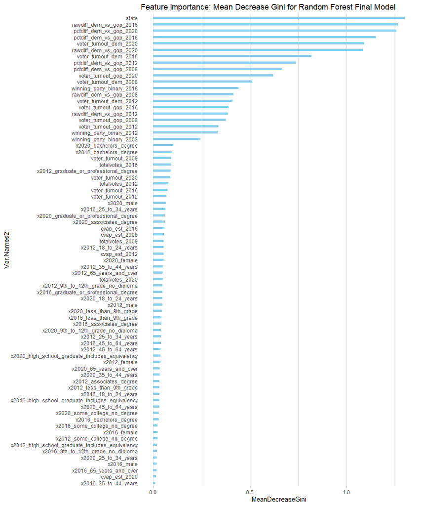

```r
#reorder variables based on MeanDecreaseGini to display in descending order
ImpData2$Var.Names2 <-
  factor(ImpData2$Var.Names,
         levels = ImpData2$Var.Names[order(ImpData2$MeanDecreaseGini,
                                           decreasing = FALSE)])

ggplot(ImpData2, aes(x=Var.Names2, y=MeanDecreaseGini)) +
  geom_segment(aes(x=Var.Names2, xend=Var.Names2, y=0, yend=MeanDecreaseGini),
               color="skyblue",
               size = 2
               ) +
  #geom_point(aes(size = IncNodePurity), color="steelblue", alpha=1) +
  theme_light() +
  coord_flip() +
  theme(
    legend.position = "bottom",
    panel.grid.major.y = element_blank(),
    panel.border = element_blank(),
    axis.ticks.y = element_blank()
  )+
  ggtitle("Feature Importance: Mean Decrease Gini for Random Forest Final Model")
```

In our second model, the top 5 attributes are state, rawdiff_dem_vs_gop_2016, pctdiff_dem_vs_gop_2020, pctdiff_dem_vs_gop_2016, voter_turnout_dem_2020.

# Prediction

```r
predictions_2024 <- predict(rf_model2, df_subset2)

#demo = 0, rep = 1
table(predictions_2024) # Republican Party
```

```
predictions_2024
 0  1
24 25
```

```r
# table(df_subset2$winning_party_binary_2020) #Democratic Party
#
# table(df_subset2$winning_party_binary_2016) #Republican Party
```

The prediction results of the model show that the Republican Party would win the 2024 elections which is true to the outcome of our elections this year.

## Model predictions by state

```r
#merge predictions back with original data
model_data3 <- model_data2

model_data3$predicted_values2024 <- predictions_2024

model_data3 <- model_data3 %>%
  mutate(prediction_2024 = if_else(predictions_2024 == 0, "Democratic Party", "Republican Party"))

state_predictions <- model_data3 %>%
  select(c(state, prediction_2024))

state_predictions%>%
  kableExtra::kable() %>%
  kableExtra::kable_minimal()
```

| state | prediction_2024 |
| --- | --- |
| Alabama | Republican Party |
| Arizona | Republican Party |
| Arkansas | Republican Party |
| California | Democratic Party |
| Colorado | Democratic Party |
| Connecticut | Democratic Party |
| Delaware | Democratic Party |
| Florida | Republican Party |
| Georgia | Democratic Party |
| Hawaii | Democratic Party |
| Idaho | Republican Party |
| Illinois | Democratic Party |
| Indiana | Republican Party |
| Iowa | Republican Party |
| Kansas | Republican Party |
| Kentucky | Republican Party |
| Louisiana | Republican Party |
| Maine | Democratic Party |
| Maryland | Democratic Party |
| Massachusetts | Democratic Party |
| Michigan | Democratic Party |
| Minnesota | Democratic Party |
| Mississippi | Republican Party |
| Missouri | Republican Party |
| Montana | Republican Party |
| Nebraska | Republican Party |
| Nevada | Democratic Party |
| New Hampshire | Democratic Party |
| New Jersey | Democratic Party |
| New Mexico | Democratic Party |
| New York | Democratic Party |
| North Carolina | Republican Party |
| North Dakota | Republican Party |
| Ohio | Republican Party |
| Oklahoma | Republican Party |
| Oregon | Democratic Party |
| Pennsylvania | Democratic Party |
| Rhode Island | Democratic Party |
| South Carolina | Republican Party |
| South Dakota | Republican Party |
| Tennessee | Republican Party |
| Texas | Republican Party |
| Utah | Republican Party |
| Vermont | Democratic Party |
| Virginia | Democratic Party |
| Washington | Democratic Party |
| West Virginia | Republican Party |
| Wisconsin | Democratic Party |
| Wyoming | Republican Party |

## Actual election results by state

```r
# Specify the URL
url <- "https://www.reuters.com/graphics/USA-ELECTION/RESULTS/zjpqnemxwvx/"

response <- GET(url)

# Parse the webpage content
webpage <- read_html(content(response, as = "text"))
```

```
No encoding supplied: defaulting to UTF-8.
```

```r
# Extract the table(s)
tables <- html_table(webpage, fill = TRUE)

tbl1 <- tables[[1]]
colnames(tbl1)[colnames(tbl1) == ""] <- "st_abbrv"
tbl1 <- tbl1 %>%
  mutate(type="Solid Democrat")

tbl2 <- tables[[2]]
colnames(tbl2)[colnames(tbl2) == ""] <- "st_abbrv"
tbl2 <- tbl2 %>%
  mutate(type="Lean Democrat")

tbl3 <- tables[[3]]
colnames(tbl3)[colnames(tbl3) == ""] <- "st_abbrv"
tbl3 <- tbl3 %>%
  mutate(type="Competitive")

tbl4 <- tables[[4]]
colnames(tbl4)[colnames(tbl4) == ""] <- "st_abbrv"
tbl4 <- tbl4 %>%
  mutate(type="Lean Republican")

tbl5 <- tables[[5]]
colnames(tbl5)[colnames(tbl5) == ""] <- "st_abbrv"
tbl5 <- tbl5 %>%
  mutate(type="Republican")

actual_results2024 <- rbind(tbl1, tbl2, tbl3, tbl4, tbl5)

# colnames(actual_results2024)[colnames(actual_results2024) == ""] <- "st_abbrv"

actual_results2024_ <- actual_results2024 %>%
  filter(!st_abbrv == "") %>%
  mutate(st_abbrv2 = case_when(st_abbrv=="D.C." ~ "District Of Columbia",
                              st_abbrv == "Md." ~ "Maryland",
                              st_abbrv == "Neb." ~ "Nebraska",
                              st_abbrv == "N.C." ~ "North Carolina",
                              st_abbrv == "N.D." ~ "North Dakota",
                              st_abbrv == "N.H." ~ "New Hampshire",
                              st_abbrv == "N.J." ~ "New Jersey",
                              st_abbrv == "N.M." ~ "New Mexico",
                              st_abbrv == "N.Y." ~ "New York",
                              st_abbrv == "Nev." ~ "Nevada",
                              st_abbrv == "Va." ~ "Virginia",
                              st_abbrv == "Vt." ~ "Vermont",
                              st_abbrv == "W.Va." ~ "West Virginia",
                              st_abbrv == "Wash." ~ "Washington",
                              TRUE ~ st_abbrv)) %>%
  arrange(st_abbrv2) %>%
  mutate(State = ls_states,
         Democrat = as.numeric(str_remove(Dem., "%"))/100,
         Republican = as.numeric(str_remove(Rep., "%"))/100,
         actual_2024 = if_else(Democrat>Republican, "Democratic Party","Republican Party")
         )

act_res24_tbl <- actual_results2024_ %>%
  select(c(State, Democrat, Republican, type, actual_2024))

act_vs_res <- left_join(act_res24_tbl, state_predictions, join_by(State==state)) %>%
  mutate(correctly_predicted = actual_2024==prediction_2024)

act_vs_res %>%
  kableExtra::kable(caption = "Final Model Predictions vs. Actual 2024 Election Results") %>%
  kableExtra::kable_paper()
```

Final Model Predictions vs. Actual 2024 Election Results

| State | Democrat | Republican | type | actual_2024 | prediction_2024 | correctly_predicted |
| --- | --- | --- | --- | --- | --- | --- |
| Alabama | 0.34 | 0.65 | Republican | Republican Party | Republican Party | TRUE |
| Alaska | 0.41 | 0.55 | Republican | Republican Party | NA | NA |
| Arizona | 0.47 | 0.52 | Competitive | Republican Party | Republican Party | TRUE |
| Arkansas | 0.34 | 0.64 | Republican | Republican Party | Republican Party | TRUE |
| California | 0.58 | 0.38 | Solid Democrat | Democratic Party | Democratic Party | TRUE |
| Colorado | 0.54 | 0.43 | Solid Democrat | Democratic Party | Democratic Party | TRUE |
| Connecticut | 0.56 | 0.42 | Solid Democrat | Democratic Party | Democratic Party | TRUE |
| Delaware | 0.57 | 0.42 | Solid Democrat | Democratic Party | Democratic Party | TRUE |
| District Of Columbia | 0.90 | 0.06 | Solid Democrat | Democratic Party | NA | NA |
| Florida | 0.43 | 0.56 | Lean Republican | Republican Party | Republican Party | TRUE |
| Georgia | 0.49 | 0.51 | Competitive | Republican Party | Democratic Party | FALSE |
| Hawaii | 0.61 | 0.37 | Solid Democrat | Democratic Party | Democratic Party | TRUE |
| Idaho | 0.30 | 0.67 | Republican | Republican Party | Republican Party | TRUE |
| Illinois | 0.55 | 0.44 | Solid Democrat | Democratic Party | Democratic Party | TRUE |
| Indiana | 0.40 | 0.59 | Republican | Republican Party | Republican Party | TRUE |
| Iowa | 0.43 | 0.56 | Republican | Republican Party | Republican Party | TRUE |
| Kansas | 0.41 | 0.57 | Republican | Republican Party | Republican Party | TRUE |
| Kentucky | 0.34 | 0.65 | Republican | Republican Party | Republican Party | TRUE |
| Louisiana | 0.38 | 0.60 | Republican | Republican Party | Republican Party | TRUE |
| Maine | 0.52 | 0.45 | Lean Democrat | Democratic Party | Democratic Party | TRUE |
| Maryland | 0.63 | 0.34 | Solid Democrat | Democratic Party | Democratic Party | TRUE |
| Massachusetts | 0.61 | 0.36 | Solid Democrat | Democratic Party | Democratic Party | TRUE |
| Michigan | 0.48 | 0.50 | Competitive | Republican Party | Democratic Party | FALSE |
| Minnesota | 0.51 | 0.47 | Competitive | Democratic Party | Democratic Party | TRUE |
| Mississippi | 0.38 | 0.61 | Republican | Republican Party | Republican Party | TRUE |
| Missouri | 0.40 | 0.58 | Republican | Republican Party | Republican Party | TRUE |
| Montana | 0.38 | 0.58 | Republican | Republican Party | Republican Party | TRUE |
| Nebraska | 0.39 | 0.59 | Republican | Republican Party | Republican Party | TRUE |
| Nevada | 0.47 | 0.51 | Competitive | Republican Party | Democratic Party | FALSE |
| New Hampshire | 0.51 | 0.48 | Lean Democrat | Democratic Party | Democratic Party | TRUE |
| New Jersey | 0.52 | 0.46 | Solid Democrat | Democratic Party | Democratic Party | TRUE |
| New Mexico | 0.52 | 0.46 | Lean Democrat | Democratic Party | Democratic Party | TRUE |
| New York | 0.56 | 0.44 | Solid Democrat | Democratic Party | Democratic Party | TRUE |
| North Carolina | 0.48 | 0.51 | Competitive | Republican Party | Republican Party | TRUE |
| North Dakota | 0.31 | 0.67 | Republican | Republican Party | Republican Party | TRUE |
| Ohio | 0.44 | 0.55 | Republican | Republican Party | Republican Party | TRUE |
| Oklahoma | 0.32 | 0.66 | Republican | Republican Party | Republican Party | TRUE |
| Oregon | 0.55 | 0.41 | Solid Democrat | Democratic Party | Democratic Party | TRUE |
| Pennsylvania | 0.49 | 0.50 | Competitive | Republican Party | Democratic Party | FALSE |
| Rhode Island | 0.56 | 0.42 | Solid Democrat | Democratic Party | Democratic Party | TRUE |
| South Carolina | 0.40 | 0.58 | Republican | Republican Party | Republican Party | TRUE |
| South Dakota | 0.34 | 0.63 | Republican | Republican Party | Republican Party | TRUE |
| Tennessee | 0.34 | 0.64 | Republican | Republican Party | Republican Party | TRUE |
| Texas | 0.42 | 0.56 | Lean Republican | Republican Party | Republican Party | TRUE |
| Utah | 0.38 | 0.59 | Republican | Republican Party | Republican Party | TRUE |
| Vermont | 0.64 | 0.32 | Solid Democrat | Democratic Party | Democratic Party | TRUE |
| Virginia | 0.52 | 0.46 | Lean Democrat | Democratic Party | Democratic Party | TRUE |
| Washington | 0.57 | 0.39 | Solid Democrat | Democratic Party | Democratic Party | TRUE |
| West Virginia | 0.28 | 0.70 | Republican | Republican Party | Republican Party | TRUE |
| Wisconsin | 0.49 | 0.50 | Competitive | Republican Party | Democratic Party | FALSE |
| Wyoming | 0.26 | 0.72 | Republican | Republican Party | Republican Party | TRUE |

```r
NA
```

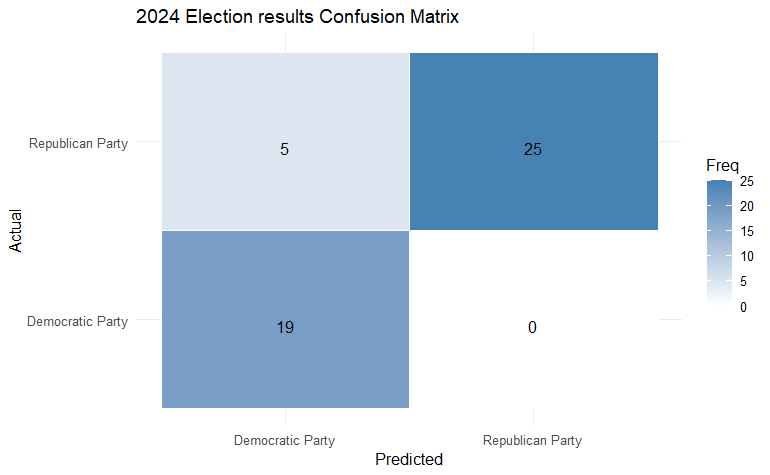

```r
act_vs_res2 <- act_vs_res %>%
  drop_na(prediction_2024) %>%
  mutate(prediction_2024 = as.factor(prediction_2024),
         actual_2024 = as.factor(actual_2024))

# Create confusion matrix
conf_matrix <- confusionMatrix(act_vs_res2$prediction_2024, act_vs_res2$actual_2024)

# Extract the confusion matrix table
cm_table <- as.data.frame(conf_matrix$table)

# Plot confusion matrix using ggplot2
ggplot(cm_table, aes(x = Prediction, y = Reference, fill = Freq)) +
  geom_tile(color = "white") +
  scale_fill_gradient(low = "white", high = "steelblue") +
  geom_text(aes(label = Freq), vjust = 1) +
  theme_minimal() +
  labs(
    title = "2024 Election results Confusion Matrix",
    x = "Predicted",
    y = "Actual"
  )
```

```r
#incorrect predictions
act_vs_res %>%
  filter(correctly_predicted== FALSE)%>%
  kableExtra::kable(caption = "Predicted vs. Actual Outcomes for Swing States (2024)" ) %>%
  kableExtra::kable_paper()
```

Predicted vs. Actual Outcomes for Swing States (2024)

| State | Democrat | Republican | type | actual_2024 | prediction_2024 | correctly_predicted |
| --- | --- | --- | --- | --- | --- | --- |
| Georgia | 0.49 | 0.51 | Competitive | Republican Party | Democratic Party | FALSE |
| Michigan | 0.48 | 0.50 | Competitive | Republican Party | Democratic Party | FALSE |
| Nevada | 0.47 | 0.51 | Competitive | Republican Party | Democratic Party | FALSE |
| Pennsylvania | 0.49 | 0.50 | Competitive | Republican Party | Democratic Party | FALSE |
| Wisconsin | 0.49 | 0.50 | Competitive | Republican Party | Democratic Party | FALSE |